# Generating SQL for SQLite using Ollama, ChromaDB

This notebook runs through the process of using the `vanna` Python package to generate SQL using AI (RAG + LLMs) including connecting to a database and training. If you're not ready to train on your own database, you can still try it using a sample SQLite database.

### Which LLM do you want to use?

- OpenAI via Vanna.AI (Recommended)

  Use Vanna.AI for free to generate your queries
- OpenAI

  Use OpenAI with your own API key
- Azure OpenAI

  If you have OpenAI models deployed on Azure
- Ollama

  Use Ollama locally for free. Requires additional setup.
- Mistral via Mistral API

  If you have a Mistral API key
- Other LLM

  If you have a different LLM model

### Where do you want to store the 'training' data?

- Vanna Hosted Vector DB (Recommended)

  Use Vanna.AIs hosted vector database (pgvector) for free. This is usable across machines with no additional setup.
- ChromaDB

  Use ChromaDBs open-source vector database for free locally. No additional setup is necessary -- all database files will be created and stored locally.
- Marqo

  Use Marqo locally for free. Requires additional setup. Or use their hosted option.
- Other VectorDB

  Use any other vector database. Requires additional setup.

## Setup

```python
import warnings
import re

warnings.filterwarnings('ignore', category=DeprecationWarning, message='^Number of requested results')
# warnings.filterwarnings('ignore', category=DeprecationWarning, message=re.escape(r'^Some regex pattern'))

import os

import re
from time import time

from vanna.ollama import Ollama
from vanna.chromadb.chromadb_vector import ChromaDB_VectorStore
```

```python
class MyVanna(ChromaDB_VectorStore, Ollama):
    def __init__(self, config=None):
        ChromaDB_VectorStore.__init__(self, config=config)
        Ollama.__init__(self, config=config)
```

```python
file_db = "~/Downloads/chinook.sqlite"
model_name = 'phi3'
```

```python
config = {
    'model': model_name,   # 'mistral' # "starcoder2"
}
vn = MyVanna(config=config)
```

```python
hostname = os.uname().nodename
print("Hostname:", hostname)
```

```
Hostname: ducklover1
```

```python
file_db = os.path.abspath(os.path.expanduser(file_db))
vn.connect_to_sqlite(file_db)
```

```python
vn.run_sql_is_set
```

```
True
```

```python
def remove_collections(collection_name=None, ACCEPTED_TYPES = ["sql", "ddl", "documentation"]):
    if not collection_name:
        collections = ACCEPTED_TYPES
    elif isinstance(collection_name, str):
        collections = [collection_name]
    elif isinstance(collection_name, list):
        collections = collection_name
    else:
        print(f"\t{collection_name} is unknown: Skipped")
        return

    for c in collections:
        if not c in ACCEPTED_TYPES:
            print(f"\t{c} is unknown: Skipped")
            continue

        # print(f"vn.remove_collection('{c}')")
        vn.remove_collection(c)
```

```python
def strip_brackets(ddl):
    """
    This function removes square brackets from table and column names in a DDL script.

    Args:
        ddl (str): The DDL script containing square brackets.

    Returns:
        str: The DDL script with square brackets removed.
    """
    # Use regular expressions to match and replace square brackets
    pattern = r"\[([^\]]+)]"  # Match any character except ] within square brackets
    return re.sub(pattern, r"\1", ddl)
```

```python
if False:
    remove_collections()
```

## Training

### [SQLite sample database](https://www.sqlitetutorial.net/sqlite-sample-database/)

You only need to train once. Do not train again unless you want to add more training data.

```python
# show training data
training_data = vn.get_training_data()
training_data
```

|  | id | question | content | training_data_type |
| --- | --- | --- | --- | --- |
| 0 | 01c4a964-460b-5e1c-af1e-622c8210b835-sql | \n Hint: album quantity is found in invoi... | SELECT i.CustomerId, COUNT(ii.InvoiceLineId) A... | sql |
| 1 | 0658ba3d-98ff-51f4-9006-a24f87045858-sql | How many customers are there | SELECT COUNT(*) FROM "customers" | sql |
| 2 | 0e1a2b7b-d65e-53de-b839-edb7afcf4ab1-sql | \n Hint: album quantity is found in invoi... | SELECT i.CustomerId, COUNT(ii.TrackId) AS Tota... | sql |
| 3 | 127fd4bd-b9af-539d-9313-1d0234d073b7-sql | \n There are 3 tables: artists, albums and... | SELECT a.Name, COUNT(t.TrackId) AS TotalTracks... | sql |
| 4 | 17d893d5-1417-5ba3-a5ca-9f6ce15a727f-sql | \n Identify artists who have albums with... | SELECT a.ArtistId, a.Name AS ArtistName\nFROM ... | sql |
| 5 | 3013d1b4-feb2-519d-bfb9-114500436e3d-sql | \n Find the customer with the most invoi... | SELECT c.CustomerId, COUNT(i.InvoiceId) AS Tot... | sql |
| 6 | 32b99e7b-31ab-55d8-8431-fb010fa7af85-sql | \n Find the top 5 customers who spent th... | SELECT c.CustomerId, SUM(i.Total) AS TotalSpen... | sql |
| 7 | 49e67df3-a604-51f8-ad01-b8f5a2043eac-sql | \n Get the total number of invoices for e... | SELECT c.CustomerId, COUNT(i.InvoiceId) AS Tot... | sql |
| 8 | 584873f8-1904-50f1-8f80-7ccf08059264-sql | \n List all customers from Canada and th... | SELECT c.Email, c.Country\nFROM "customers" c\... | sql |
| 9 | 6bed484b-9a80-57f4-ad89-5f775b5df252-sql | \n Get the average invoice total for each... | SELECT c.CustomerId, AVG(i.Total) AS AverageIn... | sql |
| 10 | 6f22268c-5062-5f11-ba2d-8555f06b409d-sql | \n Find all tracks with a name containing... | SELECT * \nFROM "tracks" \nWHERE LOWER(Name) L... | sql |
| 11 | 70b4f686-c71b-5ee8-9458-6bbc776349bf-sql | \n Find all invoices since 2010 and the t... | SELECT i.InvoiceDate, SUM(i.Total) AS TotalAmo... | sql |
| 12 | 9a396a33-ecea-51a8-bd05-28f58a86eb86-sql | \n Hint: album quantity is found in invoi... | SELECT c.CustomerId, COUNT(ii.TrackId) AS Tota... | sql |
| 13 | 9a9c970b-b94c-5f22-b54c-b86921a38b65-sql | \n Identify artists who have albums with... | SELECT a.ArtistId, a.Name AS ArtistName\nFROM ... | sql |
| 14 | a7185c88-7417-5b75-a52e-4eaef5f9deca-sql | \n List all albums and their correspondin... | SELECT a.Title, a.ArtistId, ar.Name AS ArtistN... | sql |
| 15 | aea89953-21b2-55d1-9dda-431ee6033c3d-sql | \n List all invoices with a total exceedi... | SELECT * \nFROM "invoices" \nWHERE Total > 10.00 | sql |
| 16 | d1d70c18-f5d9-5970-a32c-914deeca1087-sql | \n Find the customer who bought the most... | SELECT c.CustomerId, COUNT(ii.TrackId) AS Tota... | sql |
| 17 | d8a2f948-dffa-5524-a5f9-174cc1a8da73-sql | Can you list all tables in the SQLite database... | SELECT name FROM sqlite_master WHERE type='table' | sql |
| 18 | d8a37163-5ce5-58cd-a316-ea5598d44d27-sql | what are the top 5 countries that customers co... | SELECT c.Country, COUNT(*) AS TotalCustomers\n... | sql |
| 19 | dd282d7c-a4ef-5e3a-87e0-cb45fac50808-sql | \n Find the total number of invoices per ... | SELECT i.BillingCountry, COUNT(*) AS TotalInvo... | sql |
| 20 | e7c4b3aa-664f-5f87-8b25-449a4482f3fd-sql | \n Get all playlists containing at least... | SELECT pt.PlaylistId, p.Name AS PlaylistName, ... | sql |
| 21 | f33f8cb6-1b12-5ea7-8d9a-aef8166b9970-sql | \n Find the top 5 most expensive tracks (... | SELECT t.TrackId, t.Name, t.UnitPrice\nFROM "t... | sql |
| 22 | f626b681-4d8f-563a-beee-1ea759baaa82-sql | \n List all genres and the number of trac... | SELECT g.Name, COUNT(t.GenreId) AS TotalTracks... | sql |
| 23 | fd25ebba-4066-5a0f-8613-7b1c2ace0339-sql | \n List all employees and their reporting... | SELECT e.FirstName, e.LastName, mt.FirstName A... | sql |
| 0 | 039f9d54-59f7-5f29-8c04-14dbc3e95671-ddl | None | CREATE TABLE "artists"\r\n(\r\n ArtistId IN... | ddl |
| 1 | 0db84e3d-ef41-563c-803e-21c1b985dc19-ddl | None | CREATE TABLE "invoices"\r\n(\r\n InvoiceId ... | ddl |
| 2 | 10cba811-ddba-5042-9e90-d764dfcd1629-ddl | None | CREATE INDEX IFK_InvoiceCustomerId ON "invoice... | ddl |
| 3 | 2c711317-b93d-5f60-a728-cb1c6fcbc040-ddl | None | CREATE INDEX IFK_CustomerSupportRepId ON "cust... | ddl |
| 4 | 37319c81-65f7-50ee-956b-795de244bee5-ddl | None | CREATE TABLE sqlite_stat1(tbl,idx,stat) | ddl |
| 5 | 40bd77cd-e1de-5872-8693-624117ff413c-ddl | None | CREATE INDEX IFK_InvoiceLineInvoiceId ON "invo... | ddl |
| 6 | 41130543-7164-562a-90a7-0fd0a409c154-ddl | None | CREATE TABLE "albums"\r\n(\r\n AlbumId INTE... | ddl |
| 7 | 458debc8-8082-5450-a17a-66028bd55ace-ddl | None | CREATE TABLE "playlists"\r\n(\r\n PlaylistI... | ddl |
| 8 | 4815f3fd-925b-53ce-9dfa-0e4285d5abd3-ddl | None | CREATE TABLE "invoice_items"\r\n(\r\n Invoi... | ddl |
| 9 | 48d484e9-984c-58ff-b391-75521c69d486-ddl | None | CREATE INDEX IFK_PlaylistTrackTrackId ON "play... | ddl |
| 10 | 551e1120-a6ee-554f-8b8a-ccf4f22d3636-ddl | None | CREATE INDEX IFK_AlbumArtistId ON "albums" (Ar... | ddl |
| 11 | 5ff4911e-45c1-5a59-9566-243a9b6a3320-ddl | None | CREATE TABLE "employees"\r\n(\r\n EmployeeI... | ddl |
| 12 | 65df0648-bf05-5f75-9365-c21f54b2302d-ddl | None | CREATE TABLE "media_types"\r\n(\r\n MediaTy... | ddl |
| 13 | 6b585176-e66d-5b23-8d86-ca8a80e3af3d-ddl | None | CREATE INDEX IFK_EmployeeReportsTo ON "employe... | ddl |
| 14 | 868758b8-e018-55e7-8cc3-75c0e6d211c8-ddl | None | CREATE INDEX IFK_TrackAlbumId ON "tracks" (Alb... | ddl |
| 15 | 9ea4613d-c1be-5a77-ada9-c54ee3f0cab7-ddl | None | CREATE INDEX IFK_TrackMediaTypeId ON "tracks" ... | ddl |
| 16 | a9c9a852-608d-5ef2-aede-26ba098d83d1-ddl | None | CREATE INDEX IFK_TrackGenreId ON "tracks" (Gen... | ddl |
| 17 | b42cc9e1-9219-5a42-9a06-de906f76239e-ddl | None | CREATE TABLE "tracks"\r\n(\r\n TrackId INTE... | ddl |
| 18 | c387b9d2-5ff4-5a07-8364-f5dab45bb2a9-ddl | None | CREATE TABLE "genres"\r\n(\r\n GenreId INTE... | ddl |
| 19 | d654f328-dc36-549e-84c3-06ee0db7e0f7-ddl | None | CREATE TABLE "playlist_track"\r\n(\r\n Play... | ddl |
| 20 | d93f0d68-023d-5afb-8121-ba346699d318-ddl | None | CREATE TABLE "customers"\r\n(\r\n CustomerI... | ddl |
| 21 | e5879308-329e-543f-a693-0c14e2f9972e-ddl | None | CREATE INDEX IFK_InvoiceLineTrackId ON "invoic... | ddl |
| 22 | ea84418b-1a28-59b4-a1f4-2fb674208adc-ddl | None | CREATE TABLE sqlite_sequence(name,seq) | ddl |
| 0 | 9d2550eb-8e22-54cd-9fad-9e1be65ab03a-doc | None | In the SQLite database invoice means order | documentation |

```python
df_ddl = vn.run_sql("SELECT type, sql FROM sqlite_master WHERE sql is not null")
```

```python
df_ddl
```

|  | type | sql |
| --- | --- | --- |
| 0 | table | CREATE TABLE "albums"\r\n(\r\n [AlbumId] IN... |
| 1 | table | CREATE TABLE sqlite_sequence(name,seq) |
| 2 | table | CREATE TABLE "artists"\r\n(\r\n [ArtistId] ... |
| 3 | table | CREATE TABLE "customers"\r\n(\r\n [Customer... |
| 4 | table | CREATE TABLE "employees"\r\n(\r\n [Employee... |
| 5 | table | CREATE TABLE "genres"\r\n(\r\n [GenreId] IN... |
| 6 | table | CREATE TABLE "invoices"\r\n(\r\n [InvoiceId... |
| 7 | table | CREATE TABLE "invoice_items"\r\n(\r\n [Invo... |
| 8 | table | CREATE TABLE "media_types"\r\n(\r\n [MediaT... |
| 9 | table | CREATE TABLE "playlists"\r\n(\r\n [Playlist... |
| 10 | table | CREATE TABLE "playlist_track"\r\n(\r\n [Pla... |
| 11 | table | CREATE TABLE "tracks"\r\n(\r\n [TrackId] IN... |
| 12 | index | CREATE INDEX [IFK_AlbumArtistId] ON "albums" (... |
| 13 | index | CREATE INDEX [IFK_CustomerSupportRepId] ON "cu... |
| 14 | index | CREATE INDEX [IFK_EmployeeReportsTo] ON "emplo... |
| 15 | index | CREATE INDEX [IFK_InvoiceCustomerId] ON "invoi... |
| 16 | index | CREATE INDEX [IFK_InvoiceLineInvoiceId] ON "in... |
| 17 | index | CREATE INDEX [IFK_InvoiceLineTrackId] ON "invo... |
| 18 | index | CREATE INDEX [IFK_PlaylistTrackTrackId] ON "pl... |
| 19 | index | CREATE INDEX [IFK_TrackAlbumId] ON "tracks" ([... |
| 20 | index | CREATE INDEX [IFK_TrackGenreId] ON "tracks" ([... |
| 21 | index | CREATE INDEX [IFK_TrackMediaTypeId] ON "tracks... |
| 22 | table | CREATE TABLE sqlite_stat1(tbl,idx,stat) |

```python
if False:
    for ddl in df_ddl['sql'].to_list():
        ddl = strip_brackets(ddl)
        vn.train(ddl=ddl)
```

```python
if False:
    # Sometimes you may want to add documentation about your business terminology or definitions.
    vn.train(documentation="In the SQLite database invoice means order")
```

## Asking the AI

Whenever you ask a new question, it will find the 10 most relevant pieces of training data and use it as part of the LLM prompt to generate the SQL.

```python
ts_start = time()
```

```
SELECT name FROM sqlite_master WHERE type = 'table';
```

[output not shown]

[output not shown]

```
Add of existing embedding ID: d8a2f948-dffa-5524-a5f9-174cc1a8da73-sql
Insert of existing embedding ID: d8a2f948-dffa-5524-a5f9-174cc1a8da73-sql
```

[output not shown]

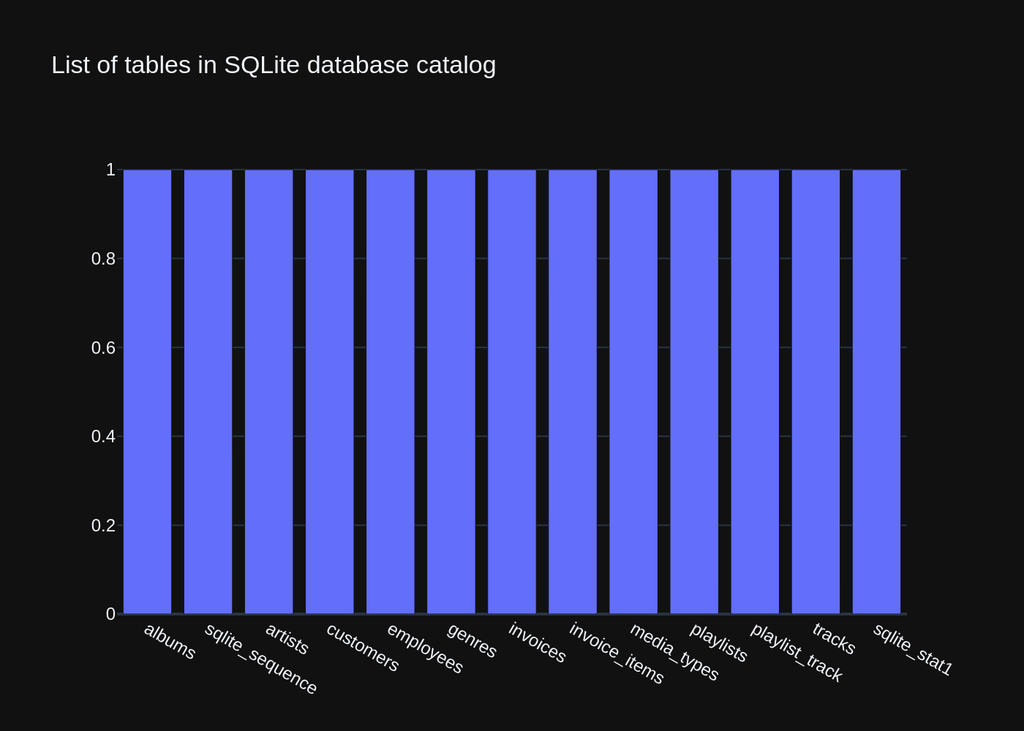

```
("SELECT name FROM sqlite_master WHERE type='table'",
                name
 0            albums
 1   sqlite_sequence
 2           artists
 3         customers
 4         employees
 5            genres
 6          invoices
 7     invoice_items
 8       media_types
 9         playlists
 10   playlist_track
 11           tracks
 12     sqlite_stat1,
 Figure({
     'data': [{'type': 'bar',
               'x': [albums, sqlite_sequence, artists, customers, employees,
                     genres, invoices, invoice_items, media_types, playlists,
                     playlist_track, tracks, sqlite_stat1],
               'y': [1, 1, 1, 1, 1, 1, 1, 1, 1, 1, 1, 1, 1]}],
     'layout': {'template': '...', 'title': {'text': 'List of tables in SQLite database catalog'}}
 }))
```

```python
vn.ask(question="Can you list all tables in the SQLite database catalog?")
```

```python
vn.ask(question="which table stores customer's orders")
```

```
Number of requested results 10 is greater than number of elements in index 1, updating n_results = 1
```

[output not shown]

```python
vn.ask(question="How many customers are there")
```

```
Number of requested results 10 is greater than number of elements in index 1, updating n_results = 1
```

[output not shown]

```python
vn.ask(question="what are the top 5 countries that customers come from?")
```

```
Number of requested results 10 is greater than number of elements in index 1, updating n_results = 1
```

[output not shown]

### More SQL questions

see `sample-sql-queries-sqlite-chinook.ipynb`

```
Number of requested results 10 is greater than number of elements in index 1, updating n_results = 1
```

[output not shown]

```
Add of existing embedding ID: a7185c88-7417-5b75-a52e-4eaef5f9deca-sql
Insert of existing embedding ID: a7185c88-7417-5b75-a52e-4eaef5f9deca-sql
```

```
Ollama Response:
{'model': 'phi3:latest', 'created_at': '2024-06-14T02:42:40.659318525Z', 'message': {'role': 'assistant', 'content': 'SELECT a.Title, a.ArtistId, ar.Name AS ArtistName\nFROM "albums" a\nJOIN "artists" ar ON a.ArtistId = ar.ArtistId;\n\nThis SQL statement retrieves the title of each album along with …
SELECT a.Title, a.ArtistId, ar.Name AS ArtistName
FROM "albums" a
JOIN "artists" ar ON a.ArtistId = ar.ArtistId;

This SQL statement retrieves the title of each album along with the associated artist's ID and name from two tables: 'albums' and 'artists'. The JOIN operation links records in both tables based on their shared 'ArtistId' field, ensuring that for every album listed, there is an accompanying artist r…
Output from LLM: SELECT a.Title, a.ArtistId, ar.Name AS ArtistName
FROM "albums" a
JOIN "artists" ar ON a.ArtistId = ar.ArtistId;

This SQL statement retrieves the title of each album along with the associated artist's ID and name from two tables: 'albums' and 'artists'. The JOIN operation links records in both tables based on their shared 'ArtistId' field, ensuring that for every album listed, there is an accompanying artist r…
Extracted SQL: SELECT a.Title, a.ArtistId, ar.Name AS ArtistName
FROM "albums" a
JOIN "artists" ar ON a.ArtistId = ar.ArtistId
SELECT a.Title, a.ArtistId, ar.Name AS ArtistName
FROM "albums" a
JOIN "artists" ar ON a.ArtistId = ar.ArtistId
                                                 Title  ArtistId  \
0                For Those About To Rock We Salute You         1
1                                    Balls to the Wall         2
2                                    Restless and Wild         2
3                                    Let There Be Rock         1
4                                             Big Ones         3
..                                                 ...       ...
342                             Respighi:Pines of Rome       226
343  Schubert: The Late String Quartets & String Qu...       272
344                                Monteverdi: L'Orfeo       273
345                              Mozart: Chamber Music       274
346  Koyaanisqatsi (Soundtrack from the Motion Pict...       275

                                            ArtistName
0                                                AC/DC
1                                               Accept
2                                               Accept
3                                                AC/DC
4                                            Aerosmith
..                                                 ...
342                                     Eugene Ormandy
343                             Emerson String Quartet
344  C. Monteverdi, Nigel Rogers - Chiaroscuro; Lon...
345                                      Nash Ensemble
346                              Philip Glass Ensemble

[347 rows x 3 columns]
Ollama parameters:
model=phi3:latest,
options={},
keep_alive=None
Prompt Content:
[{"role": "system", "content": "The following is a pandas DataFrame that contains the results of the query that answers the question the user asked: '  \n    List all albums and their corresponding artist names  \n'\n\nThe DataFrame was produced using this query: SELECT a.Title, a.ArtistId, ar.Name …
Ollama Response:
{'model': 'phi3:latest', 'created_at': '2024-06-14T02:43:02.303652975Z', 'message': {'role': 'assistant', 'content': "import plotly.express as px\n\nfig = px.bar(df, x='ArtistName', y='Title', title='Albums and Artists')\nfig.show()\n\nif df.empty:\n    fig = px.pie(values=[1], labels=['Single Value…
```

[figure not shown]

```
('SELECT a.Title, a.ArtistId, ar.Name AS ArtistName\nFROM "albums" a\nJOIN "artists" ar ON a.ArtistId = ar.ArtistId',
                                                  Title  ArtistId  \
 0                For Those About To Rock We Salute You         1
 1                                    Balls to the Wall         2
 2                                    Restless and Wild         2
 3                                    Let There Be Rock         1
 4                                             Big Ones         3
 ..                                                 ...       ...
 342                             Respighi:Pines of Rome       226
 343  Schubert: The Late String Quartets & String Qu...       272
 344                                Monteverdi: L'Orfeo       273
 345                              Mozart: Chamber Music       274
 346  Koyaanisqatsi (Soundtrack from the Motion Pict...       275

                                             ArtistName
 0                                                AC/DC
 1                                               Accept
 2                                               Accept
 3                                                AC/DC
 4                                            Aerosmith
 ..                                                 ...
 342                                     Eugene Ormandy
 343                             Emerson String Quartet
 344  C. Monteverdi, Nigel Rogers - Chiaroscuro; Lon...
 345                                      Nash Ensemble
 346                              Philip Glass Ensemble

 [347 rows x 3 columns],
 Figure({
     'data': [{'alignmentgroup': 'True',
               'hovertemplate': 'ArtistName=%{x}<br>Title=%{y}<extra></extra>',
               'legendgroup': '',
               'marker': {'color': '#636efa', 'pattern': {'shape': ''}},
               'name': '',
               'offsetgroup': '',
               'orientation': 'v',
               'showlegend': False,
               'textposition': 'auto',
               'type': 'bar',
               'x': array(['AC/DC', 'Accept', 'Accept', ...,
                           'C. Monteverdi, Nigel Rogers - Chiaroscuro; London Baroque; London Cornett & Sackbu',
                           'Nash Ensemble', 'Philip Glass Ensemble'], dtype=object),
               'xaxis': 'x',
               'y': array(['For Those About To Rock We Salute You', 'Balls to the Wall',
                           'Restless and Wild', ..., "Monteverdi: L'Orfeo",
                           'Mozart: Chamber Music',
                           'Koyaanisqatsi (Soundtrack from the Motion Picture)'], dtype=object),
               'yaxis': 'y'}],
     'layout': {'barmode': 'relative',
                'legend': {'tracegroupgap': 0},
                'template': '...',
                'title': {'text': 'Albums and Artists'},
                'xaxis': {'anchor': 'y', 'domain': [0.0, 1.0], 'title': {'text': 'ArtistName'}},
                'yaxis': {'anchor': 'x', 'domain': [0.0, 1.0], 'title': {'text': 'Title'}}}
 }))
```

```python
question = """
    List all albums and their corresponding artist names
"""

vn.ask(question=question)
```

```
Number of requested results 10 is greater than number of elements in index 1, updating n_results = 1
```

[output not shown]

```
Add of existing embedding ID: 6f22268c-5062-5f11-ba2d-8555f06b409d-sql
Insert of existing embedding ID: 6f22268c-5062-5f11-ba2d-8555f06b409d-sql
```

```
Ollama Response:
{'model': 'phi3:latest', 'created_at': '2024-06-14T02:44:05.427951064Z', 'message': {'role': 'assistant', 'content': 'SELECT * \nFROM "tracks" \nWHERE LOWER(Name) LIKE \'%what%\''}, 'done_reason': 'stop', 'done': True, 'total_duration': 62969990811, 'load_duration': 656682, 'prompt_eval_count': 1938…
SELECT *
FROM "tracks"
WHERE LOWER(Name) LIKE '%what%'
SELECT *
FROM "tracks"
WHERE LOWER(Name) LIKE '%what%'
    TrackId                                          Name  AlbumId  \
0        26                                 What It Takes        5
1        88                                  What You Are       10
2       130                             Do what cha wanna       13
3       342                   What is and Should Never Be       30
4       607                                       So What       48
5       960                                    What A Day       76
```

[output cut: 72 more lines]

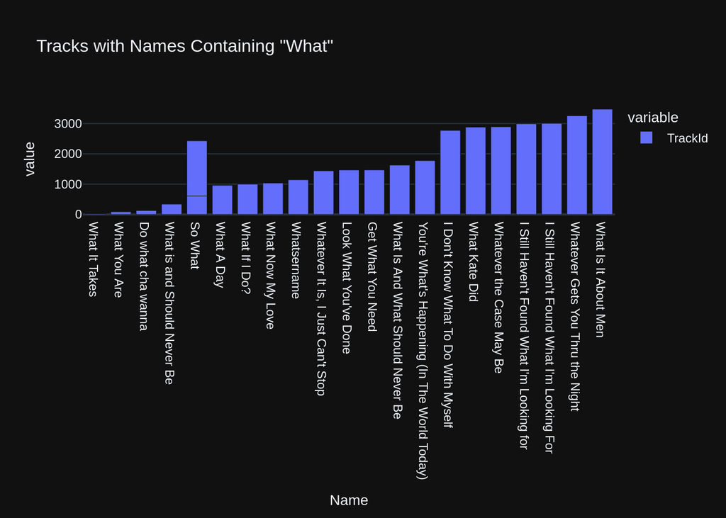

```
('SELECT * \nFROM "tracks" \nWHERE LOWER(Name) LIKE \'%what%\'',
     TrackId                                          Name  AlbumId  \
 0        26                                 What It Takes        5
 1        88                                  What You Are       10
 2       130                             Do what cha wanna       13
 3       342                   What is and Should Never Be       30
 4       607                                       So What       48
 5       960                                    What A Day       76
 6      1000                                 What If I Do?       80
 7      1039                              What Now My Love       83
 8      1145                                   Whatsername       89
 9      1440             Whatever It Is, I Just Can't Stop      116
 10     1469                         Look What You've Done      119
 11     1470                             Get What You Need      119
 12     1628              What Is And What Should Never Be      133
 13     1778  You're What's Happening (In The World Today)      146
 14     1823                                       So What      149
 15     2772           I Don't Know What To Do With Myself      223
 16     2884                                 What Kate Did      231
 17     2893                      Whatever the Case May Be      230
 18     2992    I Still Haven't Found What I'm Looking for      237
 19     3007    I Still Haven't Found What I'm Looking For      238
 20     3258              Whatever Gets You Thru the Night      255
 21     3475                          What Is It About Men      322

     MediaTypeId  GenreId                                           Composer  \
 0             1        1             Steven Tyler, Joe Perry, Desmond Child
 1             1        1                           Audioslave/Chris Cornell
 2             1        2                                        George Duke
 3             1        1                            Jimmy Page/Robert Plant
 4             1        2                                        Miles Davis
 5             1        1              Mike Bordin, Billy Gould, Mike Patton
 6             1        1  Dave Grohl, Taylor Hawkins, Nate Mendel, Chris...
 7             1       12          carl sigman/gilbert becaud/pierre leroyer
 8             1        4                                          Green Day
 9             1        1                                   Jay Kay/Kay, Jay
 10            1        4                                          N. Cester
 11            1        4                      C. Cester/C. Muncey/N. Cester
 12            1        1                           Jimmy Page, Robert Plant
 13            1       14              Allen Story/George Gordy/Robert Gordy
```

[output cut: 51 more lines]

```
                           "I Still Haven't Found What I'm Looking for",
                           "I Still Haven't Found What I'm Looking For",
                           'Whatever Gets You Thru the Night', 'What Is It About Men'],
                          dtype=object),
               'xaxis': 'x',
               'y': array([  26,   88,  130,  342,  607,  960, 1000, 1039, 1145, 1440, 1469, 1470,
                           1628, 1778, 1823, 2772, 2884, 2893, 2992, 3007, 3258, 3475]),
               'yaxis': 'y'}],
     'layout': {'barmode': 'relative',
                'legend': {'title': {'text': 'variable'}, 'tracegroupgap': 0},
                'template': '...',
                'title': {'text': 'Tracks with Names Containing "What"'},
                'xaxis': {'anchor': 'y', 'domain': [0.0, 1.0], 'title': {'text': 'Name'}},
                'yaxis': {'anchor': 'x', 'domain': [0.0, 1.0], 'title': {'text': 'value'}}}
 }))
```

```python
question = """
    Find all tracks with a name containing "What" (case-insensitive)
"""

vn.ask(question=question)
```

```
Number of requested results 10 is greater than number of elements in index 1, updating n_results = 1
```

[output not shown]

```
Add of existing embedding ID: 49e67df3-a604-51f8-ad01-b8f5a2043eac-sql
Insert of existing embedding ID: 49e67df3-a604-51f8-ad01-b8f5a2043eac-sql
```

```
Ollama Response:
{'model': 'phi3:latest', 'created_at': '2024-06-14T02:45:33.534043463Z', 'message': {'role': 'assistant', 'content': 'SELECT c.CustomerId, COUNT(i.InvoiceId) AS TotalInvoices\nFROM "customers" c\nJOIN "invoices" i ON c.CustomerId = i.CustomerId\nGROUP BY c.CustomerId;'}, 'done_reason': 'stop', 'done…
SELECT c.CustomerId, COUNT(i.InvoiceId) AS TotalInvoices
FROM "customers" c
JOIN "invoices" i ON c.CustomerId = i.CustomerId
GROUP BY c.CustomerId;
Output from LLM: SELECT c.CustomerId, COUNT(i.InvoiceId) AS TotalInvoices
FROM "customers" c
JOIN "invoices" i ON c.CustomerId = i.CustomerId
GROUP BY c.CustomerId;
Extracted SQL: SELECT c.CustomerId, COUNT(i.InvoiceId) AS TotalInvoices
FROM "customers" c
JOIN "invoices" i ON c.CustomerId = i.CustomerId
GROUP BY c.CustomerId
SELECT c.CustomerId, COUNT(i.InvoiceId) AS TotalInvoices
FROM "customers" c
JOIN "invoices" i ON c.CustomerId = i.CustomerId
GROUP BY c.CustomerId
    CustomerId  TotalInvoices
0            1              7
1            2              7
2            3              7
3            4              7
4            5              7
5            6              7
6            7              7
7            8              7
8            9              7
9           10              7
10          11              7
11          12              7
12          13              7
13          14              7
14          15              7
15          16              7
16          17              7
17          18              7
18          19              7
19          20              7
20          21              7
```

[output cut: 31 more lines]

```
52          53              7
53          54              7
54          55              7
55          56              7
56          57              7
57          58              7
58          59              6
Ollama parameters:
model=phi3:latest,
options={},
keep_alive=None
Prompt Content:
[{"role": "system", "content": "The following is a pandas DataFrame that contains the results of the query that answers the question the user asked: '  \n    Get the total number of invoices for each customer\n'\n\nThe DataFrame was produced using this query: SELECT c.CustomerId, COUNT(i.InvoiceId) …
Ollama Response:
{'model': 'phi3:latest', 'created_at': '2024-06-14T02:45:51.301740474Z', 'message': {'role': 'assistant', 'content': "import plotly.graph_objects as go\n\nfig = go.Figure()\nfig.add_trace(go.Bar(x=df['CustomerId'], y=df['TotalInvoices']))\nfig.update_layout(title='Number of Invoices per Customer')\n…
```

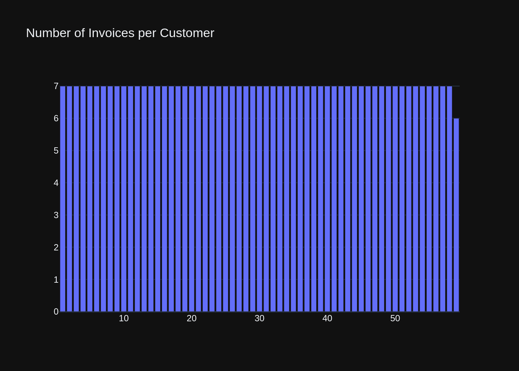

```
('SELECT c.CustomerId, COUNT(i.InvoiceId) AS TotalInvoices\nFROM "customers" c\nJOIN "invoices" i ON c.CustomerId = i.CustomerId\nGROUP BY c.CustomerId',
     CustomerId  TotalInvoices
 0            1              7
 1            2              7
 2            3              7
 3            4              7
 4            5              7
 5            6              7
 6            7              7
 7            8              7
 8            9              7
 9           10              7
 10          11              7
 11          12              7
 12          13              7
```

[output cut: 57 more lines]

```python
question = """
    Get the total number of invoices for each customer
"""

vn.ask(question=question)
```

```
Number of requested results 10 is greater than number of elements in index 1, updating n_results = 1
```

[output not shown]

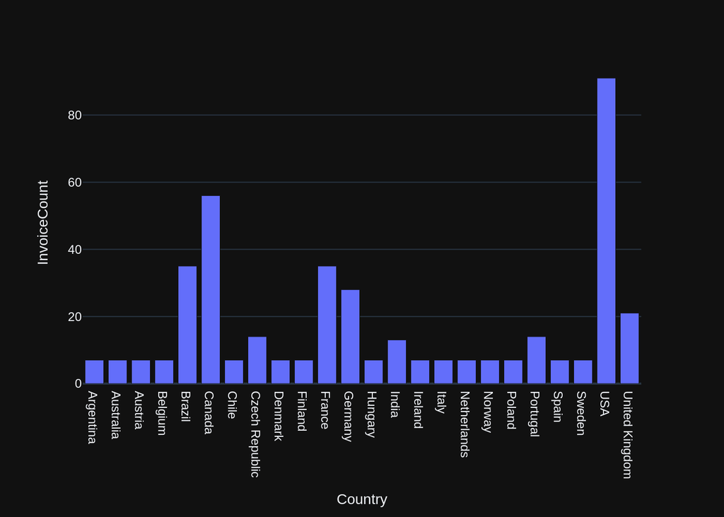

```
('SELECT Customer.Country, COUNT(invoice.InvoiceId) AS InvoiceCount\nFROM "customers" customer\nJOIN "invoices" invoice ON customer.CustomerId = invoice.CustomerId\nGROUP BY Country',
            Country  InvoiceCount
 0        Argentina             7
 1        Australia             7
 2          Austria             7
 3          Belgium             7
 4           Brazil            35
 5           Canada            56
 6            Chile             7
 7   Czech Republic            14
 8          Denmark             7
 9          Finland             7
 10          France            35
 11         Germany            28
 12         Hungary             7
 13           India            13
 14         Ireland             7
 15           Italy             7
 16     Netherlands             7
 17          Norway             7
 18          Poland             7
 19        Portugal            14
 20           Spain             7
 21          Sweden             7
 22             USA            91
 23  United Kingdom            21,
 Figure({
     'data': [{'alignmentgroup': 'True',
               'hovertemplate': 'Country=%{x}<br>InvoiceCount=%{y}<extra></extra>',
               'legendgroup': '',
               'marker': {'color': '#636efa', 'pattern': {'shape': ''}},
               'name': '',
               'offsetgroup': '',
               'orientation': 'v',
               'showlegend': False,
               'textposition': 'auto',
               'type': 'bar',
               'x': array(['Argentina', 'Australia', 'Austria', 'Belgium', 'Brazil', 'Canada',
                           'Chile', 'Czech Republic', 'Denmark', 'Finland', 'France', 'Germany',
                           'Hungary', 'India', 'Ireland', 'Italy', 'Netherlands', 'Norway',
                           'Poland', 'Portugal', 'Spain', 'Sweden', 'USA', 'United Kingdom'],
                          dtype=object),
               'xaxis': 'x',
               'y': array([ 7,  7,  7,  7, 35, 56,  7, 14,  7,  7, 35, 28,  7, 13,  7,  7,  7,  7,
                            7, 14,  7,  7, 91, 21]),
               'yaxis': 'y'}],
     'layout': {'barmode': 'relative',
                'legend': {'tracegroupgap': 0},
                'margin': {'t': 60},
                'template': '...',
                'xaxis': {'anchor': 'y', 'domain': [0.0, 1.0], 'title': {'text': 'Country'}},
                'yaxis': {'anchor': 'x', 'domain': [0.0, 1.0], 'title': {'text': 'InvoiceCount'}}}
 }))
```

```python
question = """
    Find the total number of invoices per country:
"""

vn.ask(question=question)
```

```
Number of requested results 10 is greater than number of elements in index 1, updating n_results = 1
```

[output not shown]

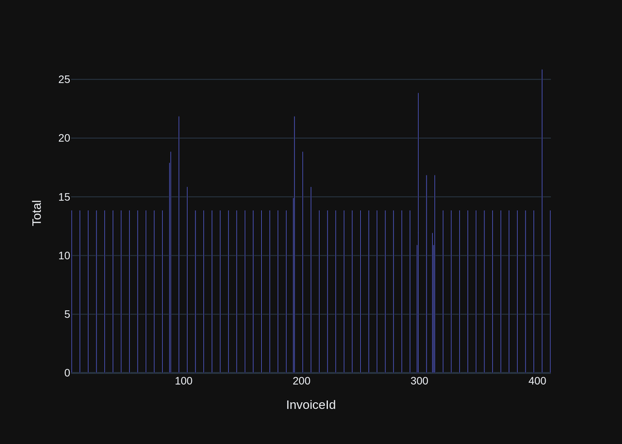

```
('SELECT *\nFROM "invoices" \nWHERE (Total > 10)\nGROUP BY InvoiceId',
     InvoiceId  CustomerId          InvoiceDate             BillingAddress  \
 0           5          23  2009-01-11 00:00:00            69 Salem Street
 1          12           2  2009-02-11 00:00:00    Theodor-Heuss-Straße 34
 2          19          40  2009-03-14 00:00:00             8, Rue Hanovre
 3          26          19  2009-04-14 00:00:00            1 Infinite Loop
 4          33          57  2009-05-15 00:00:00            Calle Lira, 198
 ..        ...         ...                  ...                        ...
 59        383          10  2013-08-12 00:00:00  Rua Dr. Falcão Filho, 155
 60        390          48  2013-09-12 00:00:00      Lijnbaansgracht 120bg
 61        397          27  2013-10-13 00:00:00            1033 N Park Ave
 62        404           6  2013-11-13 00:00:00              Rilská 3174/6
 63        411          44  2013-12-14 00:00:00            Porthaninkatu 9

    BillingCity BillingState  BillingCountry BillingPostalCode  Total
 0       Boston           MA             USA              2113  13.86
 1    Stuttgart         None         Germany             70174  13.86
 2        Paris         None          France             75002  13.86
 3    Cupertino           CA             USA             95014  13.86
 4     Santiago         None           Chile              None  13.86
 ..         ...          ...             ...               ...    ...
 59   São Paulo           SP          Brazil         01007-010  13.86
 60   Amsterdam           VV     Netherlands              1016  13.86
 61      Tucson           AZ             USA             85719  13.86
 62      Prague         None  Czech Republic             14300  25.86
 63    Helsinki         None         Finland             00530  13.86

 [64 rows x 9 columns],
 Figure({
     'data': [{'alignmentgroup': 'True',
               'hovertemplate': 'InvoiceId=%{x}<br>Total=%{y}<extra></extra>',
               'legendgroup': '',
               'marker': {'color': '#636efa', 'pattern': {'shape': ''}},
               'name': '',
               'offsetgroup': '',
               'orientation': 'v',
               'showlegend': False,
               'textposition': 'auto',
               'type': 'bar',
               'x': array([  5,  12,  19,  26,  33,  40,  47,  54,  61,  68,  75,  82,  88,  89,
                            96, 103, 110, 117, 124, 131, 138, 145, 152, 159, 166, 173, 180, 187,
                           193, 194, 201, 208, 215, 222, 229, 236, 243, 250, 257, 264, 271, 278,
                           285, 292, 298, 299, 306, 311, 312, 313, 320, 327, 334, 341, 348, 355,
                           362, 369, 376, 383, 390, 397, 404, 411]),
               'xaxis': 'x',
               'y': array([13.86, 13.86, 13.86, 13.86, 13.86, 13.86, 13.86, 13.86, 13.86, 13.86,
                           13.86, 13.86, 17.91, 18.86, 21.86, 15.86, 13.86, 13.86, 13.86, 13.86,
                           13.86, 13.86, 13.86, 13.86, 13.86, 13.86, 13.86, 13.86, 14.91, 21.86,
                           18.86, 15.86, 13.86, 13.86, 13.86, 13.86, 13.86, 13.86, 13.86, 13.86,
                           13.86, 13.86, 13.86, 13.86, 10.91, 23.86, 16.86, 11.94, 10.91, 16.86,
                           13.86, 13.86, 13.86, 13.86, 13.86, 13.86, 13.86, 13.86, 13.86, 13.86,
                           13.86, 13.86, 25.86, 13.86]),
               'yaxis': 'y'}],
     'layout': {'barmode': 'relative',
                'legend': {'tracegroupgap': 0},
                'margin': {'t': 60},
                'template': '...',
                'xaxis': {'anchor': 'y', 'domain': [0.0, 1.0], 'title': {'text': 'InvoiceId'}},
                'yaxis': {'anchor': 'x', 'domain': [0.0, 1.0], 'title': {'text': 'Total'}}}
 }))
```

```python
question = """
    List all invoices with a total exceeding $10:
"""

vn.ask(question=question)
```

```
Number of requested results 10 is greater than number of elements in index 1, updating n_results = 1
```

[output not shown]

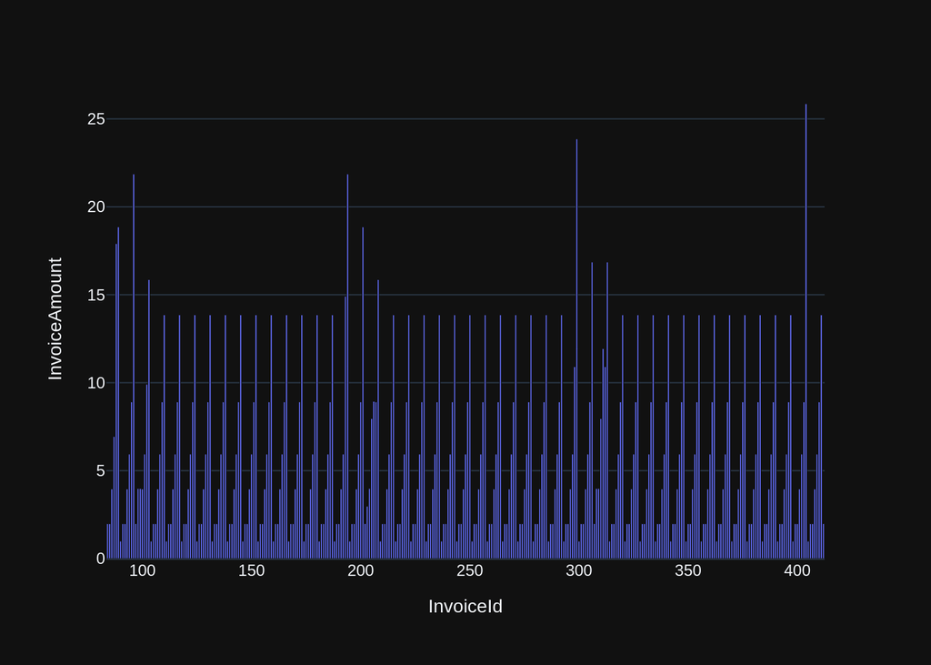

```
('SELECT i.InvoiceId, SUM(i.Total) AS InvoiceAmount\nFROM "invoices" i\nWHERE strftime(\'%Y\', i.InvoiceDate) >= \'2010\'\nGROUP BY i.InvoiceId\nORDER BY InvoiceAmount DESC',
      InvoiceId  InvoiceAmount
 0          404          25.86
 1          299          23.86
 2           96          21.86
 3          194          21.86
 4           89          18.86
 ..         ...            ...
 324        377           0.99
 325        384           0.99
 326        391           0.99
 327        398           0.99
 328        405           0.99

 [329 rows x 2 columns],
 Figure({
     'data': [{'alignmentgroup': 'True',
               'hovertemplate': 'InvoiceId=%{x}<br>InvoiceAmount=%{y}<extra></extra>',
               'legendgroup': '',
               'marker': {'color': '#636efa', 'pattern': {'shape': ''}},
               'name': '',
               'offsetgroup': '',
               'orientation': 'v',
               'showlegend': False,
               'textposition': 'auto',
               'type': 'bar',
               'x': array([404, 299,  96, ..., 391, 398, 405]),
               'xaxis': 'x',
               'y': array([25.86, 23.86, 21.86, ...,  0.99,  0.99,  0.99]),
               'yaxis': 'y'}],
     'layout': {'barmode': 'relative',
                'legend': {'tracegroupgap': 0},
                'margin': {'t': 60},
                'template': '...',
                'xaxis': {'anchor': 'y', 'domain': [0.0, 1.0], 'title': {'text': 'InvoiceId'}},
                'yaxis': {'anchor': 'x', 'domain': [0.0, 1.0], 'title': {'text': 'InvoiceAmount'}}}
 }))
```

```python
question = """
    Find all invoices since 2010 and the total amount invoiced:
"""

vn.ask(question=question)
```

```
Number of requested results 10 is greater than number of elements in index 1, updating n_results = 1
```

[output not shown]

[output cut: 17 more lines]

```
1     nancy@chinookcorp.com      Andrew Adams
2      jane@chinookcorp.com     Nancy Edwards
3  margaret@chinookcorp.com     Nancy Edwards
4     steve@chinookcorp.com     Nancy Edwards
5   michael@chinookcorp.com      Andrew Adams
6    robert@chinookcorp.com  Michael Mitchell
7     laura@chinookcorp.com  Michael Mitchell
Ollama parameters:
model=phi3:latest,
options={},
keep_alive=None
Prompt Content:
[{"role": "system", "content": "The following is a pandas DataFrame that contains the results of the query that answers the question the user asked: '  \n    List all employees and their reporting manager's name (if any):\n'\n\nThe DataFrame was produced using this query: SELECT e1.*, CONCAT(e2.Firs…
Ollama Response:
{'model': 'phi3:latest', 'created_at': '2024-06-14T02:51:54.197047431Z', 'message': {'role': 'assistant', 'content': "import plotly.graph_objects as go\n\nfig = go.Figure()\n\nfor column in df.columns:\n    if df[column].nunique() > 1:\n        fig.add_trace(go.Bar(x=df['EmployeeId'], y=df[column]))…
```

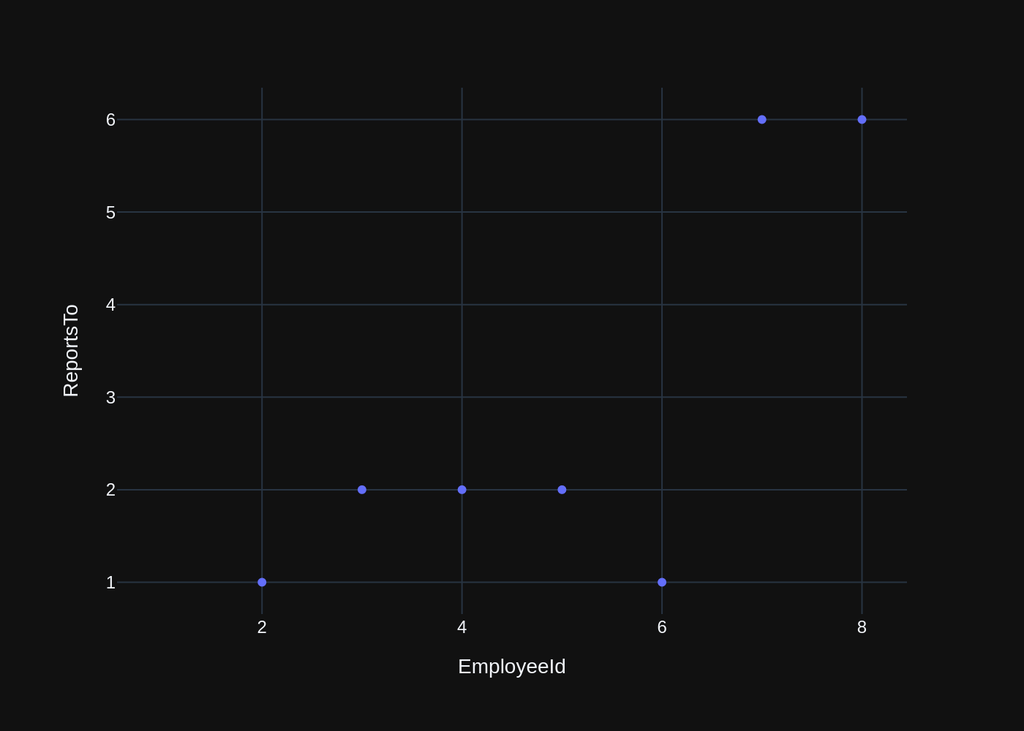

```
('SELECT e1.*, CONCAT(e2.FirstName, \' \', e2.LastName) AS ManagerName\nFROM "employees" e1\nLEFT JOIN "employees" e2 ON e1.ReportsTo = e2.EmployeeId\nORDER BY e1.EmployeeId',
    EmployeeId  LastName FirstName                Title  ReportsTo  \
 0           1     Adams    Andrew      General Manager        NaN
 1           2   Edwards     Nancy        Sales Manager        1.0
 2           3   Peacock      Jane  Sales Support Agent        2.0
 3           4      Park  Margaret  Sales Support Agent        2.0
 4           5   Johnson     Steve  Sales Support Agent        2.0
 5           6  Mitchell   Michael           IT Manager        1.0
 6           7      King    Robert             IT Staff        6.0
 7           8  Callahan     Laura             IT Staff        6.0

              BirthDate             HireDate                      Address  \
 0  1962-02-18 00:00:00  2002-08-14 00:00:00          11120 Jasper Ave NW
 1  1958-12-08 00:00:00  2002-05-01 00:00:00                 825 8 Ave SW
 2  1973-08-29 00:00:00  2002-04-01 00:00:00                1111 6 Ave SW
 3  1947-09-19 00:00:00  2003-05-03 00:00:00             683 10 Street SW
 4  1965-03-03 00:00:00  2003-10-17 00:00:00                 7727B 41 Ave
 5  1973-07-01 00:00:00  2003-10-17 00:00:00         5827 Bowness Road NW
 6  1970-05-29 00:00:00  2004-01-02 00:00:00  590 Columbia Boulevard West
 7  1968-01-09 00:00:00  2004-03-04 00:00:00                  923 7 ST NW

          City State Country PostalCode              Phone                Fax  \
 0    Edmonton    AB  Canada    T5K 2N1  +1 (780) 428-9482  +1 (780) 428-3457
 1     Calgary    AB  Canada    T2P 2T3  +1 (403) 262-3443  +1 (403) 262-3322
 2     Calgary    AB  Canada    T2P 5M5  +1 (403) 262-3443  +1 (403) 262-6712
 3     Calgary    AB  Canada    T2P 5G3  +1 (403) 263-4423  +1 (403) 263-4289
 4     Calgary    AB  Canada    T3B 1Y7   1 (780) 836-9987   1 (780) 836-9543
 5     Calgary    AB  Canada    T3B 0C5  +1 (403) 246-9887  +1 (403) 246-9899
 6  Lethbridge    AB  Canada    T1K 5N8  +1 (403) 456-9986  +1 (403) 456-8485
 7  Lethbridge    AB  Canada    T1H 1Y8  +1 (403) 467-3351  +1 (403) 467-8772

                       Email       ManagerName
 0    andrew@chinookcorp.com
 1     nancy@chinookcorp.com      Andrew Adams
 2      jane@chinookcorp.com     Nancy Edwards
 3  margaret@chinookcorp.com     Nancy Edwards
 4     steve@chinookcorp.com     Nancy Edwards
 5   michael@chinookcorp.com      Andrew Adams
 6    robert@chinookcorp.com  Michael Mitchell
 7     laura@chinookcorp.com  Michael Mitchell  ,
 Figure({
     'data': [{'hovertemplate': 'EmployeeId=%{x}<br>ReportsTo=%{y}<extra></extra>',
               'legendgroup': '',
               'marker': {'color': '#636efa', 'symbol': 'circle'},
               'mode': 'markers',
               'name': '',
               'orientation': 'v',
               'showlegend': False,
               'type': 'scatter',
               'x': array([1, 2, 3, 4, 5, 6, 7, 8]),
               'xaxis': 'x',
               'y': array([nan,  1.,  2.,  2.,  2.,  1.,  6.,  6.]),
               'yaxis': 'y'}],
     'layout': {'legend': {'tracegroupgap': 0},
                'margin': {'t': 60},
                'template': '...',
                'xaxis': {'anchor': 'y', 'domain': [0.0, 1.0], 'title': {'text': 'EmployeeId'}},
                'yaxis': {'anchor': 'x', 'domain': [0.0, 1.0], 'title': {'text': 'ReportsTo'}}}
 }))
```

```python
question = """
    List all employees and their reporting manager's name (if any):
"""

vn.ask(question=question)
```

```
Number of requested results 10 is greater than number of elements in index 1, updating n_results = 1
```

```
[{'role': 'system', 'content': 'You are a SQLite expert. Please help to generate a SQL query to answer the question. Your response should ONLY be based on the given context and follow the response guidelines and format instructions. \n===Tables \nCREATE TABLE "invoices"\r\n(\r\n    InvoiceId INTEGER…
Ollama parameters:
model=phi3:latest,
options={},
keep_alive=None
Prompt Content:
[{"role": "system", "content": "You are a SQLite expert. Please help to generate a SQL query to answer the question. Your response should ONLY be based on the given context and follow the response guidelines and format instructions. \n===Tables \nCREATE TABLE \"invoices\"\r\n(\r\n    InvoiceId INTEG…
Ollama Response:
{'model': 'phi3:latest', 'created_at': '2024-06-14T02:53:05.257778321Z', 'message': {'role': 'assistant', 'content': 'SELECT c.CustomerId, AVG(i.Total) AS AverageInvoiceTotal\nFROM "customers" c\nJOIN "invoices" i ON c.CustomerId = i.CustomerId\nGROUP BY c.CustomerId\nORDER BY AverageInvoiceTotal DE…
SELECT c.CustomerId, AVG(i.Total) AS AverageInvoiceTotal
FROM "customers" c
JOIN "invoices" i ON c.CustomerId = i.CustomerId
GROUP BY c.CustomerId
ORDER BY AverageInvoiceTotal DESC
SELECT c.CustomerId, AVG(i.Total) AS AverageInvoiceTotal
FROM "customers" c
JOIN "invoices" i ON c.CustomerId = i.CustomerId
GROUP BY c.CustomerId
ORDER BY AverageInvoiceTotal DESC
    CustomerId  AverageInvoiceTotal
0            6             7.088571
1           26             6.802857
2           57             6.660000
3           45             6.517143
4           46             6.517143
5           24             6.231429
6           28             6.231429
7           37             6.231429
8           59             6.106667
9            7             6.088571
10          25             6.088571
11          44             5.945714
12           5             5.802857
13          43             5.802857
14          48             5.802857
15           1             5.660000
16           3             5.660000
17           4             5.660000
18          17             5.660000
19          20             5.660000
```

[output cut: 32 more lines]

```
52          49             5.374286
53          50             5.374286
54          52             5.374286
55          53             5.374286
56          54             5.374286
57          55             5.374286
58          56             5.374286
Ollama parameters:
model=phi3:latest,
options={},
keep_alive=None
Prompt Content:
[{"role": "system", "content": "The following is a pandas DataFrame that contains the results of the query that answers the question the user asked: '  \n    Get the average invoice total for each customer:\n'\n\nThe DataFrame was produced using this query: SELECT c.CustomerId, AVG(i.Total) AS Avera…
Ollama Response:
{'model': 'phi3:latest', 'created_at': '2024-06-14T02:53:24.537442143Z', 'message': {'role': 'assistant', 'content': "import plotly.express as px\n\nfig = px.bar(df, x='CustomerId', y='AverageInvoiceTotal')\nfig.show()\n\nif df.shape[0] == 1:\n    fig = px.indicator(values=[df['AverageInvoiceTotal']…
```

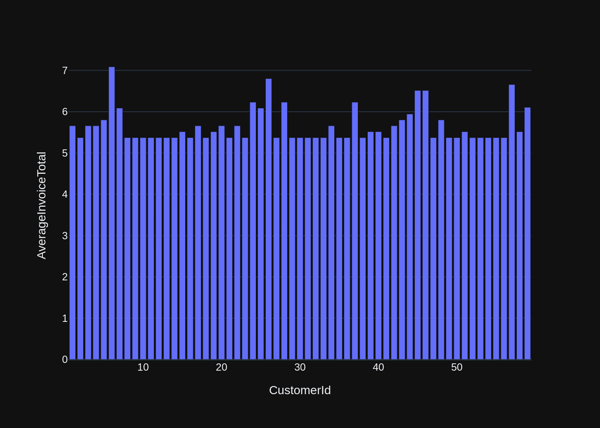

```
('SELECT c.CustomerId, AVG(i.Total) AS AverageInvoiceTotal\nFROM "customers" c\nJOIN "invoices" i ON c.CustomerId = i.CustomerId\nGROUP BY c.CustomerId\nORDER BY AverageInvoiceTotal DESC',
     CustomerId  AverageInvoiceTotal
 0            6             7.088571
 1           26             6.802857
 2           57             6.660000
 3           45             6.517143
 4           46             6.517143
 5           24             6.231429
 6           28             6.231429
 7           37             6.231429
 8           59             6.106667
 9            7             6.088571
 10          25             6.088571
 11          44             5.945714
 12           5             5.802857
 13          43             5.802857
 14          48             5.802857
 15           1             5.660000
 16           3             5.660000
 17           4             5.660000
 18          17             5.660000
 19          20             5.660000
 20          22             5.660000
 21          34             5.660000
 22          42             5.660000
 23          15             5.517143
 24          19             5.517143
 25          39             5.517143
 26          40             5.517143
 27          51             5.517143
 28          58             5.517143
 29           2             5.374286
 30           8             5.374286
 31           9             5.374286
 32          10             5.374286
 33          11             5.374286
 34          12             5.374286
 35          13             5.374286
 36          14             5.374286
 37          16             5.374286
```

[output cut: 40 more lines]

[output not shown]

```python
question = """
    Get the average invoice total for each customer:
"""

vn.ask(question=question)
```

```
Number of requested results 10 is greater than number of elements in index 1, updating n_results = 1
```

```
[{'role': 'system', 'content': 'You are a SQLite expert. Please help to generate a SQL query to answer the question. Your response should ONLY be based on the given context and follow the response guidelines and format instructions. \n===Tables \nCREATE TABLE "tracks"\r\n(\r\n    TrackId INTEGER PRI…
Ollama parameters:
model=phi3:latest,
options={},
keep_alive=None
Prompt Content:
[{"role": "system", "content": "You are a SQLite expert. Please help to generate a SQL query to answer the question. Your response should ONLY be based on the given context and follow the response guidelines and format instructions. \n===Tables \nCREATE TABLE \"tracks\"\r\n(\r\n    TrackId INTEGER P…
Ollama Response:
{'model': 'phi3:latest', 'created_at': '2024-06-14T02:54:28.34425122Z', 'message': {'role': 'assistant', 'content': 'SELECT Name, UnitPrice\nFROM "tracks"\nORDER BY UnitPrice DESC\nLIMIT 5'}, 'done_reason': 'stop', 'done': True, 'total_duration': 63715711054, 'load_duration': 766944, 'prompt_eval_co…
SELECT Name, UnitPrice
FROM "tracks"
ORDER BY UnitPrice DESC
LIMIT 5
SELECT Name, UnitPrice
FROM "tracks"
ORDER BY UnitPrice DESC
LIMIT 5
                                     Name  UnitPrice
0  Battlestar Galactica: The Story So Far       1.99
1                  Occupation / Precipice       1.99
2                           Exodus, Pt. 1       1.99
3                           Exodus, Pt. 2       1.99
4                           Collaborators       1.99
Ollama parameters:
model=phi3:latest,
options={},
keep_alive=None
Prompt Content:
[{"role": "system", "content": "The following is a pandas DataFrame that contains the results of the query that answers the question the user asked: '  \n    Find the top 5 most expensive tracks (based on unit price):\n'\n\nThe DataFrame was produced using this query: SELECT Name, UnitPrice\nFROM \"…
Ollama Response:
{'model': 'phi3:latest', 'created_at': '2024-06-14T02:54:47.307732912Z', 'message': {'role': 'assistant', 'content': "import plotly.express as px\n\nfig = px.bar(df, x='Name', y='UnitPrice')\nfig.show()\n\nif df.shape[0] == 1:\n    fig = px.pie(df, values='UnitPrice', names='Name')\n    fig.show()"}…
```

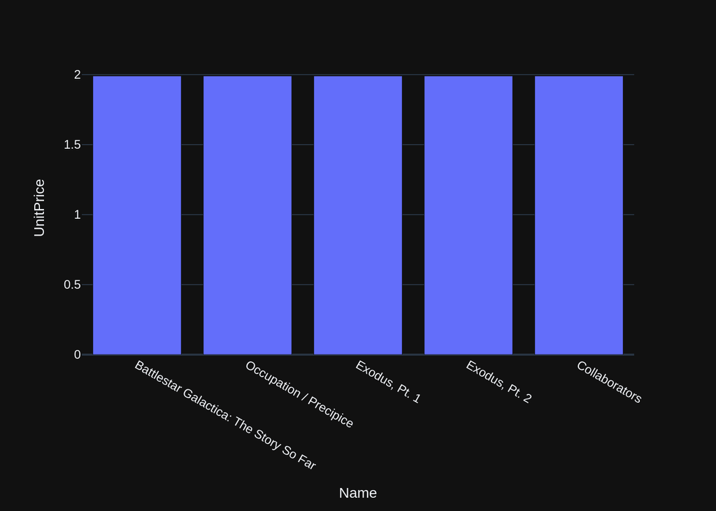

```
('SELECT Name, UnitPrice\nFROM "tracks"\nORDER BY UnitPrice DESC\nLIMIT 5',
                                      Name  UnitPrice
 0  Battlestar Galactica: The Story So Far       1.99
 1                  Occupation / Precipice       1.99
 2                           Exodus, Pt. 1       1.99
 3                           Exodus, Pt. 2       1.99
 4                           Collaborators       1.99,
 Figure({
     'data': [{'alignmentgroup': 'True',
               'hovertemplate': 'Name=%{x}<br>UnitPrice=%{y}<extra></extra>',
               'legendgroup': '',
               'marker': {'color': '#636efa', 'pattern': {'shape': ''}},
               'name': '',
               'offsetgroup': '',
               'orientation': 'v',
               'showlegend': False,
               'textposition': 'auto',
               'type': 'bar',
               'x': array(['Battlestar Galactica: The Story So Far', 'Occupation / Precipice',
                           'Exodus, Pt. 1', 'Exodus, Pt. 2', 'Collaborators'], dtype=object),
               'xaxis': 'x',
               'y': array([1.99, 1.99, 1.99, 1.99, 1.99]),
               'yaxis': 'y'}],
     'layout': {'barmode': 'relative',
                'legend': {'tracegroupgap': 0},
                'margin': {'t': 60},
                'template': '...',
                'xaxis': {'anchor': 'y', 'domain': [0.0, 1.0], 'title': {'text': 'Name'}},
                'yaxis': {'anchor': 'x', 'domain': [0.0, 1.0], 'title': {'text': 'UnitPrice'}}}
 }))
```

```python
question = """
    Find the top 5 most expensive tracks (based on unit price):
"""

vn.ask(question=question)
```

```
Number of requested results 10 is greater than number of elements in index 1, updating n_results = 1
```

```
[{'role': 'system', 'content': 'You are a SQLite expert. Please help to generate a SQL query to answer the question. Your response should ONLY be based on the given context and follow the response guidelines and format instructions. \n===Tables \nCREATE TABLE "tracks"\r\n(\r\n    TrackId INTEGER PRI…
Ollama parameters:
model=phi3:latest,
options={},
keep_alive=None
Prompt Content:
[{"role": "system", "content": "You are a SQLite expert. Please help to generate a SQL query to answer the question. Your response should ONLY be based on the given context and follow the response guidelines and format instructions. \n===Tables \nCREATE TABLE \"tracks\"\r\n(\r\n    TrackId INTEGER P…
Ollama Response:
{'model': 'phi3:latest', 'created_at': '2024-06-14T02:56:03.874317138Z', 'message': {'role': 'assistant', 'content': 'SELECT g.Name, COUNT(t.GenreId) AS TotalTracks\nFROM "genres" g\nJOIN "tracks" t ON g.GenreId = t.GenreId\nGROUP BY g.Name\nORDER BY TotalTracks DESC\nLIMIT 5'}, 'done_reason': 'stop…
SELECT g.Name, COUNT(t.GenreId) AS TotalTracks
FROM "genres" g
JOIN "tracks" t ON g.GenreId = t.GenreId
GROUP BY g.Name
ORDER BY TotalTracks DESC
LIMIT 5
SELECT g.Name, COUNT(t.GenreId) AS TotalTracks
FROM "genres" g
JOIN "tracks" t ON g.GenreId = t.GenreId
GROUP BY g.Name
ORDER BY TotalTracks DESC
LIMIT 5
                 Name  TotalTracks
0                Rock         1297
1               Latin          579
2               Metal          374
3  Alternative & Punk          332
4                Jazz          130
Ollama parameters:
model=phi3:latest,
options={},
keep_alive=None
Prompt Content:
[{"role": "system", "content": "The following is a pandas DataFrame that contains the results of the query that answers the question the user asked: '  \n    List all genres and the number of tracks in each genre:\n'\n\nThe DataFrame was produced using this query: SELECT g.Name, COUNT(t.GenreId) AS …
Ollama Response:
{'model': 'phi3:latest', 'created_at': '2024-06-14T02:56:14.258979158Z', 'message': {'role': 'assistant', 'content': "import plotly.express as px\n\nfig = px.bar(df, x='Name', y='TotalTracks')\nfig.show()"}, 'done_reason': 'stop', 'done': True, 'total_duration': 10356818959, 'load_duration': 739541,…
```

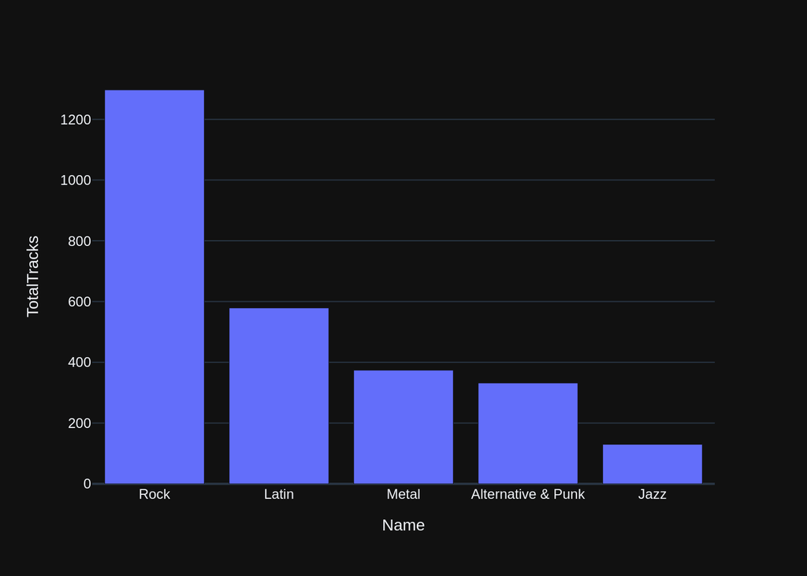

```
('SELECT g.Name, COUNT(t.GenreId) AS TotalTracks\nFROM "genres" g\nJOIN "tracks" t ON g.GenreId = t.GenreId\nGROUP BY g.Name\nORDER BY TotalTracks DESC\nLIMIT 5',
                  Name  TotalTracks
 0                Rock         1297
 1               Latin          579
 2               Metal          374
 3  Alternative & Punk          332
 4                Jazz          130,
 Figure({
     'data': [{'alignmentgroup': 'True',
               'hovertemplate': 'Name=%{x}<br>TotalTracks=%{y}<extra></extra>',
               'legendgroup': '',
               'marker': {'color': '#636efa', 'pattern': {'shape': ''}},
               'name': '',
               'offsetgroup': '',
               'orientation': 'v',
               'showlegend': False,
               'textposition': 'auto',
               'type': 'bar',
               'x': array(['Rock', 'Latin', 'Metal', 'Alternative & Punk', 'Jazz'], dtype=object),
               'xaxis': 'x',
               'y': array([1297,  579,  374,  332,  130]),
               'yaxis': 'y'}],
     'layout': {'barmode': 'relative',
                'legend': {'tracegroupgap': 0},
                'margin': {'t': 60},
                'template': '...',
                'xaxis': {'anchor': 'y', 'domain': [0.0, 1.0], 'title': {'text': 'Name'}},
                'yaxis': {'anchor': 'x', 'domain': [0.0, 1.0], 'title': {'text': 'TotalTracks'}}}
 }))
```

```python
question = """
    List all genres and the number of tracks in each genre:
"""

vn.ask(question=question)
```

```python
question = """
    Get all genres that do not have any tracks associated with them:
"""

vn.ask(question=question)
```

```
Number of requested results 10 is greater than number of elements in index 1, updating n_results = 1
```

```
[{'role': 'system', 'content': 'You are a SQLite expert. Please help to generate a SQL query to answer the question. Your response should ONLY be based on the given context and follow the response guidelines and format instructions. \n===Tables \nCREATE INDEX IFK_TrackGenreId ON "tracks" (GenreId)\n…
Ollama parameters:
model=phi3:latest,
options={},
keep_alive=None
Prompt Content:
[{"role": "system", "content": "You are a SQLite expert. Please help to generate a SQL query to answer the question. Your response should ONLY be based on the given context and follow the response guidelines and format instructions. \n===Tables \nCREATE INDEX IFK_TrackGenreId ON \"tracks\" (GenreId)…
Ollama Response:
{'model': 'phi3:latest', 'created_at': '2024-06-14T02:57:22.060360304Z', 'message': {'role': 'assistant', 'content': 'SELECT g.Name\nFROM "genres" g\nLEFT JOIN "tracks" t ON g.GenreId = t.GenreId\nWHERE t.TrackId IS NULL;\nThis query will return the names of genres without any associated tracks in t…
SELECT g.Name
FROM "genres" g
LEFT JOIN "tracks" t ON g.GenreId = t.GenreId
WHERE t.TrackId IS NULL;
This query will return the names of genres without any associated tracks in the database. The LEFT JOIN ensures that all records from 'genres' are included, even if there is no matching record in the 'tracks' table (which would be represented by a NULL value for TrackId).
Output from LLM: SELECT g.Name
FROM "genres" g
LEFT JOIN "tracks" t ON g.GenreId = t.GenreId
WHERE t.TrackId IS NULL;
This query will return the names of genres without any associated tracks in the database. The LEFT JOIN ensures that all records from 'genres' are included, even if there is no matching record in the 'tracks' table (which would be represented by a NULL value for TrackId).
Extracted SQL: SELECT g.Name
FROM "genres" g
LEFT JOIN "tracks" t ON g.GenreId = t.GenreId
WHERE t.TrackId IS NULL
SELECT g.Name
FROM "genres" g
LEFT JOIN "tracks" t ON g.GenreId = t.GenreId
WHERE t.TrackId IS NULL
Empty DataFrame
Columns: [Name]
Index: []
Ollama parameters:
model=phi3:latest,
options={},
keep_alive=None
Prompt Content:
[{"role": "system", "content": "The following is a pandas DataFrame that contains the results of the query that answers the question the user asked: '  \n    Get all genres that do not have any tracks associated with them:\n'\n\nThe DataFrame was produced using this query: SELECT g.Name\nFROM \"genr…
Ollama Response:
{'model': 'phi3:latest', 'created_at': '2024-06-14T02:57:32.411946629Z', 'message': {'role': 'assistant', 'content': "import plotly.express as px\n\nfig = px.bar(df, x='Name', y=1)\nfig.show()"}, 'done_reason': 'stop', 'done': True, 'total_duration': 10349392532, 'load_duration': 944340, 'prompt_eva…
```

```
('SELECT g.Name\nFROM "genres" g\nLEFT JOIN "tracks" t ON g.GenreId = t.GenreId\nWHERE t.TrackId IS NULL',
 Empty DataFrame
 Columns: [Name]
 Index: [],
 Figure({
     'data': [{'domain': {'x': [0.0, 1.0], 'y': [0.0, 1.0]},
               'hovertemplate': 'Name=%{label}<extra></extra>',
               'labels': array([], dtype=object),
               'legendgroup': '',
               'name': '',
               'showlegend': True,
               'type': 'pie'}],
     'layout': {'legend': {'tracegroupgap': 0}, 'margin': {'t': 60}, 'template': '...'}
 }))
```

```python
question = """
    List all customers who have not placed any orders:
"""

vn.ask(question=question)
```

```
Number of requested results 10 is greater than number of elements in index 1, updating n_results = 1
```

```
[{'role': 'system', 'content': 'You are a SQLite expert. Please help to generate a SQL query to answer the question. Your response should ONLY be based on the given context and follow the response guidelines and format instructions. \n===Tables \nCREATE TABLE "invoices"\r\n(\r\n    InvoiceId INTEGER…
Ollama parameters:
model=phi3:latest,
options={},
keep_alive=None
Prompt Content:
[{"role": "system", "content": "You are a SQLite expert. Please help to generate a SQL query to answer the question. Your response should ONLY be based on the given context and follow the response guidelines and format instructions. \n===Tables \nCREATE TABLE \"invoices\"\r\n(\r\n    InvoiceId INTEG…
Ollama Response:
{'model': 'phi3:latest', 'created_at': '2024-06-14T02:58:37.487559094Z', 'message': {'role': 'assistant', 'content': 'SELECT * FROM "customers" WHERE CustomerId NOT IN (SELECT DISTINCT CustomerId FROM "invoices")'}, 'done_reason': 'stop', 'done': True, 'total_duration': 64994590906, 'load_duration':…
SELECT * FROM "customers" WHERE CustomerId NOT IN (SELECT DISTINCT CustomerId FROM "invoices")
SELECT * FROM "customers" WHERE CustomerId NOT IN (SELECT DISTINCT CustomerId FROM "invoices")
Empty DataFrame
Columns: [CustomerId, FirstName, LastName, Company, Address, City, State, Country, PostalCode, Phone, Fax, Email, SupportRepId]
Index: []
Ollama parameters:
model=phi3:latest,
options={},
keep_alive=None
Prompt Content:
[{"role": "system", "content": "The following is a pandas DataFrame that contains the results of the query that answers the question the user asked: '  \n    List all customers who have not placed any orders:\n'\n\nThe DataFrame was produced using this query: SELECT * FROM \"customers\" WHERE Custom…
Ollama Response:
{'model': 'phi3:latest', 'created_at': '2024-06-14T02:58:55.259605946Z', 'message': {'role': 'assistant', 'content': "import plotly.express as px\n\nfig = px.bar(df.groupby('CustomerId').size(), title='Customers who have not placed any orders', x='CustomerId', y='count')\nfig.update_layout(showlegen…
```

```
('SELECT * FROM "customers" WHERE CustomerId NOT IN (SELECT DISTINCT CustomerId FROM "invoices")',
 Empty DataFrame
 Columns: [CustomerId, FirstName, LastName, Company, Address, City, State, Country, PostalCode, Phone, Fax, Email, SupportRepId]
 Index: [],
 Figure({
     'data': [{'domain': {'x': [0.0, 1.0], 'y': [0.0, 1.0]},
               'hovertemplate': 'CustomerId=%{label}<extra></extra>',
               'labels': array([], dtype=object),
               'legendgroup': '',
               'name': '',
               'showlegend': True,
               'type': 'pie'}],
     'layout': {'legend': {'tracegroupgap': 0}, 'margin': {'t': 60}, 'template': '...'}
 }))
```

```python
question = """
    There are 3 tables: artists, albums and tracks, where albums and artists are linked by ArtistId, albums and tracks are linked by AlbumId,
    Can you find the top 10 most popular artists based on the number of tracks
"""

vn.ask(question=question)
```

```
Number of requested results 10 is greater than number of elements in index 1, updating n_results = 1
```

```
[{'role': 'system', 'content': 'You are a SQLite expert. Please help to generate a SQL query to answer the question. Your response should ONLY be based on the given context and follow the response guidelines and format instructions. \n===Tables \nCREATE TABLE "tracks"\r\n(\r\n    TrackId INTEGER PRI…
Ollama parameters:
model=phi3:latest,
options={},
keep_alive=None
Prompt Content:
[{"role": "system", "content": "You are a SQLite expert. Please help to generate a SQL query to answer the question. Your response should ONLY be based on the given context and follow the response guidelines and format instructions. \n===Tables \nCREATE TABLE \"tracks\"\r\n(\r\n    TrackId INTEGER P…
Ollama Response:
{'model': 'phi3:latest', 'created_at': '2024-06-14T03:00:14.457769248Z', 'message': {'role': 'assistant', 'content': 'SELECT a.ArtistId, a.Name AS ArtistName, COUNT(t.TrackId) AS NumberOfTracks\nFROM "artists" a\nJOIN "albums" al ON a.ArtistId = al.ArtistId\nJOIN "tracks" t ON al.AlbumId = t.AlbumId…
SELECT a.ArtistId, a.Name AS ArtistName, COUNT(t.TrackId) AS NumberOfTracks
FROM "artists" a
JOIN "albums" al ON a.ArtistId = al.ArtistId
JOIN "tracks" t ON al.AlbumId = t.AlbumId
GROUP BY a.ArtistId, a EXPLAIN TOP 10 ORDER BY NumberOfTracks DESC
SELECT a.ArtistId, a.Name AS ArtistName, COUNT(t.TrackId) AS NumberOfTracks
FROM "artists" a
JOIN "albums" al ON a.ArtistId = al.ArtistId
JOIN "tracks" t ON al.AlbumId = t.AlbumId
GROUP BY a.ArtistId, a EXPLAIN TOP 10 ORDER BY NumberOfTracks DESC
Couldn't run sql:  Execution failed on sql 'SELECT a.ArtistId, a.Name AS ArtistName, COUNT(t.TrackId) AS NumberOfTracks
FROM "artists" a
JOIN "albums" al ON a.ArtistId = al.ArtistId
JOIN "tracks" t ON al.AlbumId = t.AlbumId
GROUP BY a.ArtistId, a EXPLAIN TOP 10 ORDER BY NumberOfTracks DESC': near "EXPLAIN": syntax error
```

```
Number of requested results 10 is greater than number of elements in index 1, updating n_results = 1
```

````
[{'role': 'system', 'content': 'You are a SQLite expert. Please help to generate a SQL query to answer the question. Your response should ONLY be based on the given context and follow the response guidelines and format instructions. \n===Tables \nCREATE INDEX IFK_CustomerSupportRepId ON "customers" …
Ollama parameters:
model=phi3:latest,
options={},
keep_alive=None
Prompt Content:
[{"role": "system", "content": "You are a SQLite expert. Please help to generate a SQL query to answer the question. Your response should ONLY be based on the given context and follow the response guidelines and format instructions. \n===Tables \nCREATE INDEX IFK_CustomerSupportRepId ON \"customers\…
Ollama Response:
{'model': 'phi3:latest', 'created_at': '2024-06-14T03:01:52.247458969Z', 'message': {'role': 'assistant', 'content': 'SELECT * FROM "customers" WHERE Country=\'Canada\' AND Email IS NOT NULL;\n\n==========\nTo find the customer who has placed orders with the highest total price, we can join the \'Cu…
SELECT * FROM "customers" WHERE Country='Canada' AND Email IS NOT NULL;

==========
To find the customer who has placed orders with the highest total price, we can join the 'Customers', 'Invoices', and 'InvoiceItems' tables. The 'TotalPrice' of an invoice is calculated by summing up all the item prices on that particular invoice:

```sql
SELECT c.CustomerId, c.Email, SUM(i.Total) AS TotalSpent
FROM Customers c
JOIN Invoices i ON c.CustomerId = i.CustomerId
GROUP BY c.CustomerId
ORDER BY TotalSpent DESC
LIMIT 1;
```
This query calculates the total spent per customer by summing up invoice totals and then orders the result in descending order to get the top spender at the first row, which is selected thanks to `LIMIT 1`.
Output from LLM: SELECT * FROM "customers" WHERE Country='Canada' AND Email IS NOT NULL;

==========
To find the customer who has placed orders with the highest total price, we can join the 'Customers', 'Invoices', and 'InvoiceItems' tables. The 'TotalPrice' of an invoice is calculated by summing up all the item prices on that particular invoice:

```sql
SELECT c.CustomerId, c.Email, SUM(i.Total) AS TotalSpent
FROM Customers c
JOIN Invoices i ON c.CustomerId = i.CustomerId
GROUP BY c.CustomerId
ORDER BY TotalSpent DESC
LIMIT 1;
```
This query calculates the total spent per customer by summing up invoice totals and then orders the result in descending order to get the top spender at the first row, which is selected thanks to `LIMIT 1`.
Extracted SQL: SELECT c.CustomerId, c.Email, SUM(i.Total) AS TotalSpent
FROM Customers c
JOIN Invoices i ON c.CustomerId = i.CustomerId
GROUP BY c.CustomerId
ORDER BY TotalSpent DESC
LIMIT 1
SELECT c.CustomerId, c.Email, SUM(i.Total) AS TotalSpent
FROM Customers c
JOIN Invoices i ON c.CustomerId = i.CustomerId
GROUP BY c.CustomerId
ORDER BY TotalSpent DESC
LIMIT 1
   CustomerId            Email  TotalSpent
0           6  hholy@gmail.com       49.62
Ollama parameters:
model=phi3:latest,
options={},
keep_alive=None
Prompt Content:
[{"role": "system", "content": "The following is a pandas DataFrame that contains the results of the query that answers the question the user asked: '  \n     List all customers from Canada and their email addresses:\n'\n\nThe DataFrame was produced using this query: SELECT c.CustomerId, c.Email, SU…
Ollama Response:
{'model': 'phi3:latest', 'created_at': '2024-06-14T03:02:18.808056032Z', 'message': {'role': 'assistant', 'content': '```python\nimport plotly.express as px\n\n# Assuming df has more than one row for this to work properly\nif len(df) > 1:\n    fig = px.bar(df, x=\'CustomerId\', y=\'TotalSpent\', tex…
````

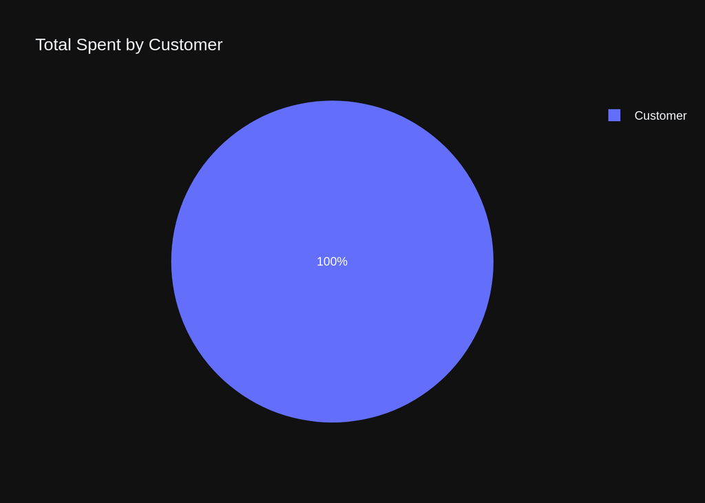

```
('SELECT c.CustomerId, c.Email, SUM(i.Total) AS TotalSpent\nFROM Customers c\nJOIN Invoices i ON c.CustomerId = i.CustomerId\nGROUP BY c.CustomerId\nORDER BY TotalSpent DESC\nLIMIT 1',
    CustomerId            Email  TotalSpent
 0           6  hholy@gmail.com       49.62,
 Figure({
     'data': [{'domain': {'x': [0.0, 1.0], 'y': [0.0, 1.0]},
               'hovertemplate': 'label=%{label}<br>TotalSpent=%{value}<extra></extra>',
               'labels': array(['Customer'], dtype=object),
               'legendgroup': '',
               'name': '',
               'showlegend': True,
               'type': 'pie',
               'values': array([49.62])}],
     'layout': {'legend': {'tracegroupgap': 0}, 'template': '...', 'title': {'text': 'Total Spent by Customer'}}
 }))
```

```python
question = """
     List all customers from Canada and their email addresses:
"""

vn.ask(question=question)
```

```
Number of requested results 10 is greater than number of elements in index 1, updating n_results = 1
```

```
[{'role': 'system', 'content': 'You are a SQLite expert. Please help to generate a SQL query to answer the question. Your response should ONLY be based on the given context and follow the response guidelines and format instructions. \n===Tables \nCREATE TABLE "invoices"\r\n(\r\n    InvoiceId INTEGER…
Ollama parameters:
model=phi3:latest,
options={},
keep_alive=None
Prompt Content:
[{"role": "system", "content": "You are a SQLite expert. Please help to generate a SQL query to answer the question. Your response should ONLY be based on the given context and follow the response guidelines and format instructions. \n===Tables \nCREATE TABLE \"invoices\"\r\n(\r\n    InvoiceId INTEG…
Ollama Response:
{'model': 'phi3:latest', 'created_at': '2024-06-14T03:03:26.573105112Z', 'message': {'role': 'assistant', 'content': 'SELECT CustomerId, COUNT(InvoiceId) AS NumberOfInvoices \nFROM Invoices \nGROUP BY CustomerId\nORDER BY NumberOfInvoices DESC\nLIMIT 1\n-------------------------'}, 'done_reason': 's…
SELECT CustomerId, COUNT(InvoiceId) AS NumberOfInvoices
FROM Invoices
GROUP BY CustomerId
ORDER BY NumberOfInvoices DESC
LIMIT 1
-------------------------
SELECT CustomerId, COUNT(InvoiceId) AS NumberOfInvoices
FROM Invoices
GROUP BY CustomerId
ORDER BY NumberOfInvoices DESC
LIMIT 1
-------------------------
   CustomerId  NumberOfInvoices
0           1                 7
Ollama parameters:
model=phi3:latest,
options={},
keep_alive=None
Prompt Content:
[{"role": "system", "content": "The following is a pandas DataFrame that contains the results of the query that answers the question the user asked: '  \n     Find the customer with the most invoices \n'\n\nThe DataFrame was produced using this query: SELECT CustomerId, COUNT(InvoiceId) AS NumberOfI…
Ollama Response:
{'model': 'phi3:latest', 'created_at': '2024-06-14T03:03:45.515380033Z', 'message': {'role': 'assistant', 'content': "import plotly.express as px\n\nfig = px.bar(df, x='CustomerId', y='NumberOfInvoices')\nfig.show()\n\nif len(df) == 1:\n    fig = px.pie(df, values='NumberOfInvoices', names='Customer…
```

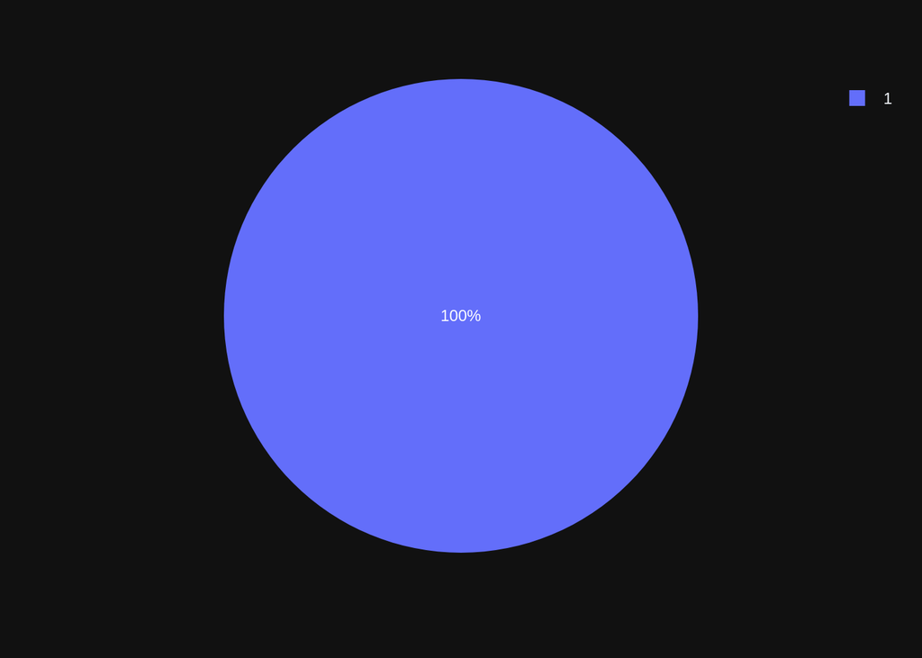

```
('SELECT CustomerId, COUNT(InvoiceId) AS NumberOfInvoices \nFROM Invoices \nGROUP BY CustomerId\nORDER BY NumberOfInvoices DESC\nLIMIT 1\n-------------------------',
    CustomerId  NumberOfInvoices
 0           1                 7,
 Figure({
     'data': [{'domain': {'x': [0.0, 1.0], 'y': [0.0, 1.0]},
               'hovertemplate': 'CustomerId=%{label}<br>NumberOfInvoices=%{value}<extra></extra>',
               'labels': array([1]),
               'legendgroup': '',
               'name': '',
               'showlegend': True,
               'type': 'pie',
               'values': array([7])}],
     'layout': {'legend': {'tracegroupgap': 0}, 'margin': {'t': 60}, 'template': '...'}
 }))
```

```python
question = """
     Find the customer with the most invoices
"""

vn.ask(question=question)
```

### Advanced SQL questions

```
Number of requested results 10 is greater than number of elements in index 1, updating n_results = 1
```

````
[{'role': 'system', 'content': 'You are a SQLite expert. Please help to generate a SQL query to answer the question. Your response should ONLY be based on the given context and follow the response guidelines and format instructions. \n===Tables \nCREATE TABLE "tracks"\r\n(\r\n    TrackId INTEGER PRI…
Ollama parameters:
model=phi3:latest,
options={},
keep_alive=None
Prompt Content:
[{"role": "system", "content": "You are a SQLite expert. Please help to generate a SQL query to answer the question. Your response should ONLY be based on the given context and follow the response guidelines and format instructions. \n===Tables \nCREATE TABLE \"tracks\"\r\n(\r\n    TrackId INTEGER P…
Ollama Response:
{'model': 'phi3:latest', 'created_at': '2024-06-14T03:04:58.281757195Z', 'message': {'role': 'assistant', 'content': 'SELECT i.CustomerId, COUNT(ii.TrackId) AS TotalAlbums\nFROM "invoices" i\nJOIN "invoice_items" ii ON i.InvoiceId = ii.InvoiceId\nGROUP BY i.CustomerId\nORDER BY TotalAlbums DESC\nLIM…
SELECT i.CustomerId, COUNT(ii.TrackId) AS TotalAlbums
FROM "invoices" i
JOIN "invoice_items" ii ON i.InvoiceId = ii.InvoiceId
GROUP BY i.CustomerId
ORDER BY TotalAlbums DESC
LIMIT 1
-------------------------
SELECT i.CustomerId, COUNT(ii.TrackId) AS TotalAlbums
FROM "invoices" i
JOIN "invoice_items" ii ON i.InvoiceId = ii.InvoiceId
GROUP BY i.CustomerId
ORDER BY TotalAlbums DESC
LIMIT 1
-------------------------
   CustomerId  TotalAlbums
0           1           38
Ollama parameters:
model=phi3:latest,
options={},
keep_alive=None
Prompt Content:
[{"role": "system", "content": "The following is a pandas DataFrame that contains the results of the query that answers the question the user asked: '  \n     Find the customer who bought the most albums in total quantity (across all invoices): \n'\n\nThe DataFrame was produced using this query: SEL…
Ollama Response:
{'model': 'phi3:latest', 'created_at': '2024-06-14T03:05:28.957211703Z', 'message': {'role': 'assistant', 'content': "```python\nimport plotly.express as px\n\nfig = px.bar(df, x='CustomerId', y='TotalAlbums')\nfig.update_layout(title_text='Most Albums Bought by Customer')\nfig.show()\n```\n\nIn cas…
````

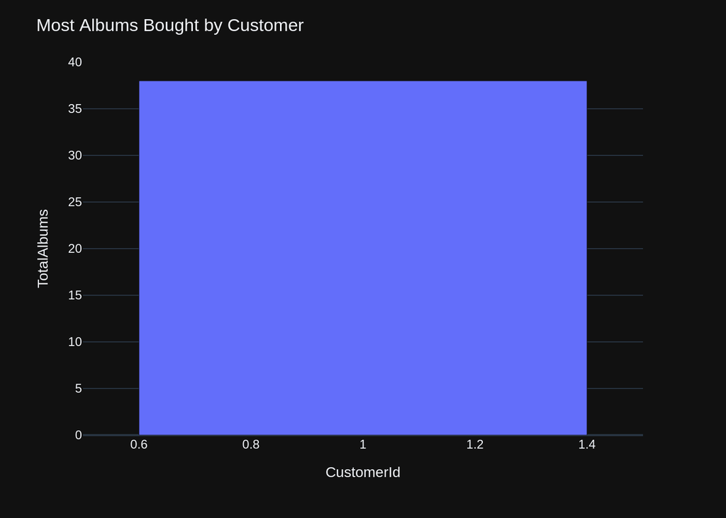

```
('SELECT i.CustomerId, COUNT(ii.TrackId) AS TotalAlbums\nFROM "invoices" i\nJOIN "invoice_items" ii ON i.InvoiceId = ii.InvoiceId\nGROUP BY i.CustomerId\nORDER BY TotalAlbums DESC\nLIMIT 1\n-------------------------',
    CustomerId  TotalAlbums
 0           1           38,
 Figure({
     'data': [{'alignmentgroup': 'True',
               'hovertemplate': 'CustomerId=%{x}<br>TotalAlbums=%{y}<extra></extra>',
               'legendgroup': '',
               'marker': {'color': '#636efa', 'pattern': {'shape': ''}},
               'name': '',
               'offsetgroup': '',
               'orientation': 'v',
               'showlegend': False,
               'textposition': 'auto',
               'type': 'bar',
               'x': array([1]),
               'xaxis': 'x',
               'y': array([38]),
               'yaxis': 'y'}],
     'layout': {'barmode': 'relative',
                'legend': {'tracegroupgap': 0},
                'margin': {'t': 60},
                'template': '...',
                'title': {'text': 'Most Albums Bought by Customer'},
                'xaxis': {'anchor': 'y', 'domain': [0.0, 1.0], 'title': {'text': 'CustomerId'}},
                'yaxis': {'anchor': 'x', 'domain': [0.0, 1.0], 'title': {'text': 'TotalAlbums'}}}
 }))
```

```python
question = """
     Find the customer who bought the most albums in total quantity (across all invoices):
"""

vn.ask(question=question)
```

```
Number of requested results 10 is greater than number of elements in index 1, updating n_results = 1
```

````
[{'role': 'system', 'content': 'You are a SQLite expert. Please help to generate a SQL query to answer the question. Your response should ONLY be based on the given context and follow the response guidelines and format instructions. \n===Tables \nCREATE TABLE "invoice_items"\r\n(\r\n    InvoiceLineI…
Ollama parameters:
model=phi3:latest,
options={},
keep_alive=None
Prompt Content:
[{"role": "system", "content": "You are a SQLite expert. Please help to generate a SQL query to answer the question. Your response should ONLY be based on the given context and follow the response guidelines and format instructions. \n===Tables \nCREATE TABLE \"invoice_items\"\r\n(\r\n    InvoiceLin…
Ollama Response:
{'model': 'phi3:latest', 'created_at': '2024-06-14T03:06:37.29021214Z', 'message': {'role': 'assistant', 'content': 'SELECT i.CustomerId, COUNT(ii.TrackId) AS TotalAlbums\nFROM "invoices" i\nJOIN "invoice_items" ii ON i.InvoiceId = ii.InvoiceId\nGROUP BY i.CustomerId\nORDER BY TotalAlbums DESC\nLIMI…
SELECT i.CustomerId, COUNT(ii.TrackId) AS TotalAlbums
FROM "invoices" i
JOIN "invoice_items" ii ON i.InvoiceId = ii.InvoiceId
GROUP BY i.CustomerId
ORDER BY TotalAlbums DESC
LIMIT 5
-------------------------
SELECT i.CustomerId, COUNT(ii.TrackId) AS TotalAlbums
FROM "invoices" i
JOIN "invoice_items" ii ON i.InvoiceId = ii.InvoiceId
GROUP BY i.CustomerId
ORDER BY TotalAlbums DESC
LIMIT 5
-------------------------
   CustomerId  TotalAlbums
0           1           38
1           2           38
2           3           38
3           4           38
4           5           38
Ollama parameters:
model=phi3:latest,
options={},
keep_alive=None
Prompt Content:
[{"role": "system", "content": "The following is a pandas DataFrame that contains the results of the query that answers the question the user asked: '  \n    Hint: album quantity is found in invoice_items, \n    \n    Find the top 5 customers who bought the most albums in total quantity (across all …
Ollama Response:
{'model': 'phi3:latest', 'created_at': '2024-06-14T03:06:58.152142826Z', 'message': {'role': 'assistant', 'content': "```python\nimport plotly.express as px\n\n# Assuming df has been preprocessed to have a single row if needed for indicator charting\nfig = px.bar(df, x='CustomerId', y='TotalAlbums')…
````

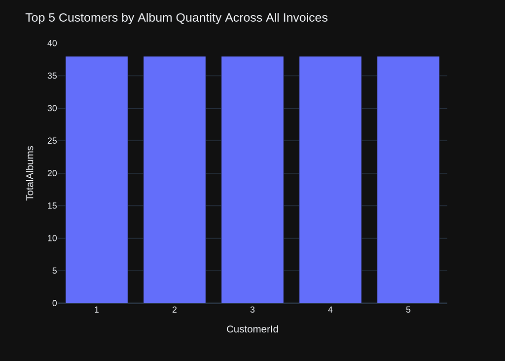

```
('SELECT i.CustomerId, COUNT(ii.TrackId) AS TotalAlbums\nFROM "invoices" i\nJOIN "invoice_items" ii ON i.InvoiceId = ii.InvoiceId\nGROUP BY i.CustomerId\nORDER BY TotalAlbums DESC\nLIMIT 5\n-------------------------',
    CustomerId  TotalAlbums
 0           1           38
 1           2           38
 2           3           38
 3           4           38
 4           5           38,
 Figure({
     'data': [{'alignmentgroup': 'True',
               'hovertemplate': 'CustomerId=%{x}<br>TotalAlbums=%{y}<extra></extra>',
               'legendgroup': '',
               'marker': {'color': '#636efa', 'pattern': {'shape': ''}},
               'name': '',
               'offsetgroup': '',
               'orientation': 'v',
               'showlegend': False,
               'textposition': 'auto',
               'type': 'bar',
               'x': array([1, 2, 3, 4, 5]),
               'xaxis': 'x',
               'y': array([38, 38, 38, 38, 38]),
               'yaxis': 'y'}],
     'layout': {'barmode': 'relative',
                'legend': {'tracegroupgap': 0},
                'margin': {'t': 60},
                'template': '...',
                'title': {'text': 'Top 5 Customers by Album Quantity Across All Invoices'},
                'xaxis': {'anchor': 'y', 'domain': [0.0, 1.0], 'title': {'text': 'CustomerId'}},
                'yaxis': {'anchor': 'x', 'domain': [0.0, 1.0], 'title': {'text': 'TotalAlbums'}}}
 }))
```

```python
question = """
    Hint: album quantity is found in invoice_items,

    Find the top 5 customers who bought the most albums in total quantity (across all invoices):
"""

vn.ask(question=question)
```

```
SELECT c.CustomerId, SUM(il.Quantity) AS TotalAlbums
FROM Customers c
JOIN invoices i  ON c.CustomerId = i.CustomerId
JOIN invoice_items il ON i.InvoiceId = il.InvoiceId
GROUP BY c.CustomerId
ORDER BY TotalAlbums DESC
LIMIT 5
```

```
Number of requested results 10 is greater than number of elements in index 1, updating n_results = 1
```

```
[{'role': 'system', 'content': 'You are a SQLite expert. Please help to generate a SQL query to answer the question. Your response should ONLY be based on the given context and follow the response guidelines and format instructions. \n===Tables \nCREATE TABLE "invoices"\r\n(\r\n    InvoiceId INTEGER…
Ollama parameters:
model=phi3:latest,
options={},
keep_alive=None
Prompt Content:
[{"role": "system", "content": "You are a SQLite expert. Please help to generate a SQL query to answer the question. Your response should ONLY be based on the given context and follow the response guidelines and format instructions. \n===Tables \nCREATE TABLE \"invoices\"\r\n(\r\n    InvoiceId INTEG…
Ollama Response:
{'model': 'phi3:latest', 'created_at': '2024-06-14T03:08:05.28787172Z', 'message': {'role': 'assistant', 'content': 'SELECT c.CustomerId, SUM(i.Total) AS TotalSpent\nFROM "customers" c\nJOIN "invoices" i ON c.CustomerId = i.CustomerId\nGROUP BY c.CustomerId\nORDER BY TotalSpent DESC\nLIMIT 5\n------…
SELECT c.CustomerId, SUM(i.Total) AS TotalSpent
FROM "customers" c
JOIN "invoices" i ON c.CustomerId = i.CustomerId
GROUP BY c.CustomerId
ORDER BY TotalSpent DESC
LIMIT 5
-------------------------
SELECT c.CustomerId, SUM(i.Total) AS TotalSpent
FROM "customers" c
JOIN "invoices" i ON c.CustomerId = i.CustomerId
GROUP BY c.CustomerId
ORDER BY TotalSpent DESC
LIMIT 5
-------------------------
   CustomerId  TotalSpent
0           6       49.62
1          26       47.62
2          57       46.62
3          45       45.62
4          46       45.62
Ollama parameters:
model=phi3:latest,
options={},
keep_alive=None
Prompt Content:
[{"role": "system", "content": "The following is a pandas DataFrame that contains the results of the query that answers the question the user asked: '  \n     Find the top 5 customers who spent the most money overall, \n     \n     Hint: order total can be found on invoices table, calculation using …
Ollama Response:
{'model': 'phi3:latest', 'created_at': '2024-06-14T03:08:23.096401435Z', 'message': {'role': 'assistant', 'content': "import plotly.graph_objs as go\n\ntrace = go.Bar(x=df['CustomerId'], y=df['TotalSpent'])\ndata = [trace]\nlayout = go.Layout(title='Top 5 Customers by Total Spend')\nfig = go.Figure(…
```

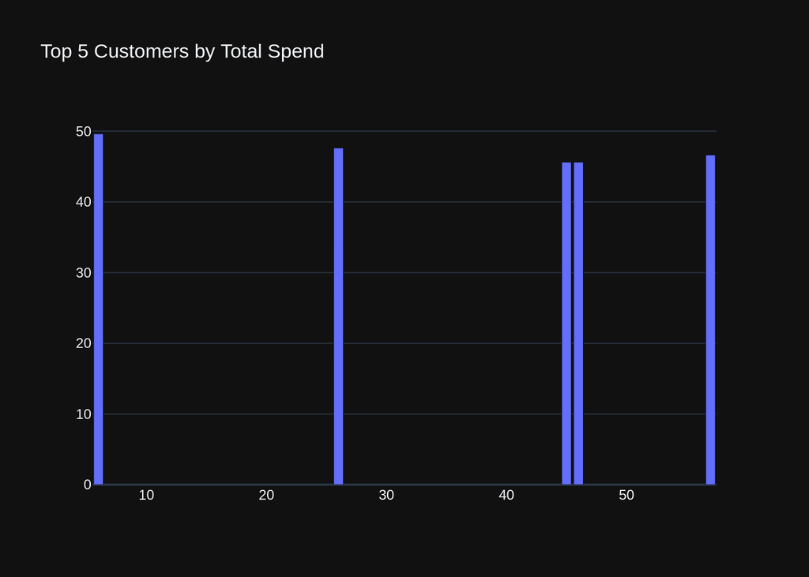

```
('SELECT c.CustomerId, SUM(i.Total) AS TotalSpent\nFROM "customers" c\nJOIN "invoices" i ON c.CustomerId = i.CustomerId\nGROUP BY c.CustomerId\nORDER BY TotalSpent DESC\nLIMIT 5\n-------------------------',
    CustomerId  TotalSpent
 0           6       49.62
 1          26       47.62
 2          57       46.62
 3          45       45.62
 4          46       45.62,
 Figure({
     'data': [{'type': 'bar', 'x': array([ 6, 26, 57, 45, 46]), 'y': array([49.62, 47.62, 46.62, 45.62, 45.62])}],
     'layout': {'template': '...', 'title': {'text': 'Top 5 Customers by Total Spend'}}
 }))
```

```python
question = """
     Find the top 5 customers who spent the most money overall,

     Hint: order total can be found on invoices table, calculation using invoice_items detail table is unnecessary
"""

vn.ask(question=question)
```

```python
question = """
     Get all playlists containing at least 10 tracks and the total duration of those tracks:
"""

vn.ask(question=question)
```

```
Number of requested results 10 is greater than number of elements in index 1, updating n_results = 1
```

```
[{'role': 'system', 'content': 'You are a SQLite expert. Please help to generate a SQL query to answer the question. Your response should ONLY be based on the given context and follow the response guidelines and format instructions. \n===Tables \nCREATE INDEX IFK_PlaylistTrackTrackId ON "playlist_tr…
Ollama parameters:
model=phi3:latest,
options={},
keep_alive=None
Prompt Content:
[{"role": "system", "content": "You are a SQLite expert. Please help to generate a SQL query to answer the question. Your response should ONLY be based on the given context and follow the response guidelines and format instructions. \n===Tables \nCREATE INDEX IFK_PlaylistTrackTrackId ON \"playlist_t…
Ollama Response:
{'model': 'phi3:latest', 'created_at': '2024-06-14T03:09:33.778384012Z', 'message': {'role': 'assistant', 'content': 'SELECT p.PlaylistId, SUM(t.Milliseconds) AS TotalDuration\nFROM "playlist_track" ptt JOIN "tracks" t ON ptt.TrackId = t.TrackId\nGROUP BY p.PlaylistId\nHAVING COUNT(ptt.TrackId) >= 1…
SELECT p.PlaylistId, SUM(t.Milliseconds) AS TotalDuration
FROM "playlist_track" ptt JOIN "tracks" t ON ptt.TrackId = t.TrackId
GROUP BY p.PlaylistId
HAVING COUNT(ptt.TrackId) >= 10
ORDER BY TotalDuration DESC
LIMIT 5
SELECT p.PlaylistId, SUM(t.Milliseconds) AS TotalDuration
FROM "playlist_track" ptt JOIN "tracks" t ON ptt.TrackId = t.TrackId
GROUP BY p.PlaylistId
HAVING COUNT(ptt.TrackId) >= 10
ORDER BY TotalDuration DESC
LIMIT 5
Couldn't run sql:  Execution failed on sql 'SELECT p.PlaylistId, SUM(t.Milliseconds) AS TotalDuration
FROM "playlist_track" ptt JOIN "tracks" t ON ptt.TrackId = t.TrackId
GROUP BY p.PlaylistId
HAVING COUNT(ptt.TrackId) >= 10
ORDER BY TotalDuration DESC
LIMIT 5': no such column: p.PlaylistId
```

```python
question = """
     Identify artists who have albums with tracks appearing in multiple genres:


"""

vn.ask(question=question)
```

```
Number of requested results 10 is greater than number of elements in index 1, updating n_results = 1
```

```
[{'role': 'system', 'content': 'You are a SQLite expert. Please help to generate a SQL query to answer the question. Your response should ONLY be based on the given context and follow the response guidelines and format instructions. \n===Tables \nCREATE TABLE "tracks"\r\n(\r\n    TrackId INTEGER PRI…
Ollama parameters:
model=phi3:latest,
options={},
keep_alive=None
Prompt Content:
[{"role": "system", "content": "You are a SQLite expert. Please help to generate a SQL query to answer the question. Your response should ONLY be based on the given context and follow the response guidelines and format instructions. \n===Tables \nCREATE TABLE \"tracks\"\r\n(\r\n    TrackId INTEGER P…
Ollama Response:
{'model': 'phi3:latest', 'created_at': '2024-06-14T03:10:59.204861487Z', 'message': {'role': 'assistant', 'content': 'SELECT DISTINCT a.ArtistId, a.Name AS ArtistName\nFROM "artists" a\nWHERE EXISTS (\n  SELECT g2.GenreId\n  FROM "genres" g2\n  JOIN "tracks" t ON g2.GenreId = t.GenreId\n  WHERE a.Ar…
SELECT DISTINCT a.ArtistId, a.Name AS ArtistName
FROM "artists" a
WHERE EXISTS (
  SELECT g2.GenreId
  FROM "genres" g2
  JOIN "tracks" t ON g2.GenreId = t.GenreId
  WHERE a.ArtistId = (
    SELECT al.ArtistId
    FROM "albums" al
    WHERE al.AlbumId IN (SELECT t.AlbumId FROM "tracks" t)
      AND EXISTS (
        SELECT 1
        FROM "genres" g
        WHERE t.GenreId = g.GenreId
          AND COUNT(g.GenreId) > 1
    )
  )
)
ORDER BY ArtistName;
Output from LLM: SELECT DISTINCT a.ArtistId, a.Name AS ArtistName
FROM "artists" a
WHERE EXISTS (
  SELECT g2.GenreId
  FROM "genres" g2
  JOIN "tracks" t ON g2.GenreId = t.GenreId
  WHERE a.ArtistId = (
    SELECT al.ArtistId
    FROM "albums" al
    WHERE al.AlbumId IN (SELECT t.AlbumId FROM "tracks" t)
      AND EXISTS (
        SELECT 1
```

[output cut: 49 more lines]

[output not shown]

### Check completion time

```python
ts_stop = time()

elapsed_time = ts_stop - ts_start
print(f"test running on '{hostname}' with '{model_name}' LLM took : {elapsed_time:.2f} sec")
```

```
test running on 'ducklover1' with 'phi3' LLM took : 2083.60 sec
```

## Launch the User Interface

[figure not shown]

## Next Steps

Using Vanna via Jupyter notebooks is great for getting started but check out additional customizable interfaces like the

- [Streamlit app](https://github.com/vanna-ai/vanna-streamlit)
- [Flask app](https://github.com/vanna-ai/vanna-flask)
- [Slackbot](https://github.com/vanna-ai/vanna-slack)